# Predict Bike Sharing Demand with AutoGluon Template

## Project: Predict Bike Sharing Demand with AutoGluon

This notebook is a template with each step that you need to complete for the project.

Please fill in your code where there are explicit `?` markers in the notebook. You are welcome to add more cells and code as you see fit.

Once you have completed all the code implementations, please export your notebook as a HTML file so the reviews can view your code. Make sure you have all outputs correctly outputted.

`File-> Export Notebook As... -> Export Notebook as HTML`

There is a writeup to complete as well after all code implememtation is done. Please answer all questions and attach the necessary tables and charts. You can complete the writeup in either markdown or PDF.

Completing the code template and writeup template will cover all of the rubric points for this project.

The rubric contains "Stand Out Suggestions" for enhancing the project beyond the minimum requirements. The stand out suggestions are optional. If you decide to pursue the "stand out suggestions", you can include the code in this notebook and also discuss the results in the writeup file.

## Step 1: Create an account with Kaggle

### Create Kaggle Account and download API key

Below is example of steps to get the API username and key. Each student will have their own username and key.

1. Open account settings.

2. Scroll down to API and click Create New API Token.

3. Open up `kaggle.json` and use the username and key.

## Step 2: Download the Kaggle dataset using the kaggle python library

### Open up Sagemaker Studio and use starter template

1. Notebook should be using a `ml.t3.medium` instance (2 vCPU + 4 GiB)
2. Notebook should be using kernal: `Python 3 (MXNet 1.8 Python 3.7 CPU Optimized)`

### Install packages

```python
!pip install -U pip
!pip install -U setuptools wheel
#!pip install -U "mxnet<2.0.0" bokeh==2.0.1
#!pip install bokeh==2.0.1
!pip install autogluon #--no-cache-dir
# Without --no-cache-dir, smaller aws instances may have trouble installing
!pip install kaggle
```

[output not shown]

[output not shown]

[output not shown]

[output not shown]

[output not shown]

[output not shown]

[output not shown]

[output not shown]

[output not shown]

[output not shown]

[output not shown]

[output not shown]

[output not shown]

[output not shown]

[output not shown]

[output not shown]

[output not shown]

[output not shown]

[output not shown]

[output not shown]

[output not shown]

[output not shown]

[output not shown]

[output not shown]

[output not shown]

[output not shown]

[output not shown]

[output not shown]

[output not shown]

[output not shown]

[output not shown]

[output not shown]

[output not shown]

[output not shown]

[output not shown]

[output not shown]

[output not shown]

[output not shown]

[output not shown]

[output not shown]

[output not shown]

[output not shown]

[output not shown]

[output not shown]

[output not shown]

[output not shown]

[output not shown]

[output not shown]

[output not shown]

[output not shown]

[output not shown]

[output not shown]

[output not shown]

[output not shown]

[output not shown]

[output not shown]

[output not shown]

[output not shown]

[output not shown]

[output not shown]

[output not shown]

[output not shown]

[output not shown]

[output not shown]

[output not shown]

[output not shown]

[output not shown]

[output not shown]

[output not shown]

[output not shown]

[output not shown]

[output not shown]

[output not shown]

[output not shown]

[output not shown]

[output not shown]

[output not shown]

[output not shown]

[output not shown]

[output not shown]

[output not shown]

[output not shown]

[output not shown]

[output not shown]

[output not shown]

[output not shown]

[output not shown]

[output not shown]

[output not shown]

[output not shown]

[output not shown]

[output not shown]

[output not shown]

[output not shown]

[output not shown]

[output not shown]

[output not shown]

[output not shown]

[output not shown]

[output not shown]

[output not shown]

[output not shown]

[output not shown]

[output not shown]

[output not shown]

[output not shown]

[output not shown]

[output not shown]

[output not shown]

[output not shown]

[output not shown]

[output not shown]

[output not shown]

[output not shown]

[output not shown]

[output not shown]

[output not shown]

[output not shown]

[output not shown]

[output not shown]

[output not shown]

[output not shown]

[output not shown]

[output not shown]

[output not shown]

[output not shown]

### Setup Kaggle API Key

```python
!mkdir -p ~/.kaggle
!touch ~/.kaggle/kaggle.json
!chmod 600 ~/.kaggle/kaggle.json
```

```python
# Fill in your user name and key from creating the kaggle account and API token file
import json
kaggle_username = "michaelmatela"
kaggle_key = "431e8047d7bac85d95bcaa2f7d3982ae"

# Save API token the kaggle.json file
#with open("/root/.kaggle/kaggle.json", "w") as f:
with open("/home/sagemaker-user/.kaggle/kaggle.json", "w") as f:
    f.write(json.dumps({"username": kaggle_username, "key": kaggle_key}))
```

### Download and explore dataset

### Go to the bike sharing demand competition and agree to the terms

```python
# Download the dataset, it will be in a .zip file so you'll need to unzip it as well.
#!kaggle competitions download --force -c bike-sharing-demand
!kaggle competitions download -c bike-sharing-demand
# If you already downloaded it you can use the -o command to overwrite the file
!unzip -o bike-sharing-demand.zip
```

```
Downloading bike-sharing-demand.zip to /home/sagemaker-user/Bike-Sharing-Demand/project
```

```
Archive:  bike-sharing-demand.zip
  inflating: sampleSubmission.csv
  inflating: test.csv
  inflating: train.csv
```

```python
import pandas as pd
import matplotlib.pyplot as plt
import matplotlib.dates as mdates
import seaborn as sns
from autogluon.tabular import TabularPredictor
import gc
```

```python
# Create the train dataset in pandas by reading the csv
# Set the parsing of the datetime column so you can use some of the `dt` features in pandas later
train = pd.read_csv("train.csv")
train["datetime"] = pd.to_datetime(train["datetime"])
train.head()
```

|  | datetime | season | holiday | workingday | weather | temp | atemp | humidity | windspeed | casual | registered | count |
| --- | --- | --- | --- | --- | --- | --- | --- | --- | --- | --- | --- | --- |
| 0 | 2011-01-01 00:00:00 | 1 | 0 | 0 | 1 | 9.84 | 14.395 | 81 | 0.0 | 3 | 13 | 16 |
| 1 | 2011-01-01 01:00:00 | 1 | 0 | 0 | 1 | 9.02 | 13.635 | 80 | 0.0 | 8 | 32 | 40 |
| 2 | 2011-01-01 02:00:00 | 1 | 0 | 0 | 1 | 9.02 | 13.635 | 80 | 0.0 | 5 | 27 | 32 |
| 3 | 2011-01-01 03:00:00 | 1 | 0 | 0 | 1 | 9.84 | 14.395 | 75 | 0.0 | 3 | 10 | 13 |
| 4 | 2011-01-01 04:00:00 | 1 | 0 | 0 | 1 | 9.84 | 14.395 | 75 | 0.0 | 0 | 1 | 1 |

```python
# Create the test pandas dataframe in pandas by reading the csv, remember to parse the datetime!
test = pd.read_csv("test.csv")
test["datetime"] = pd.to_datetime(test["datetime"])
test.head()
```

|  | datetime | season | holiday | workingday | weather | temp | atemp | humidity | windspeed |
| --- | --- | --- | --- | --- | --- | --- | --- | --- | --- |
| 0 | 2011-01-20 00:00:00 | 1 | 0 | 1 | 1 | 10.66 | 11.365 | 56 | 26.0027 |
| 1 | 2011-01-20 01:00:00 | 1 | 0 | 1 | 1 | 10.66 | 13.635 | 56 | 0.0000 |
| 2 | 2011-01-20 02:00:00 | 1 | 0 | 1 | 1 | 10.66 | 13.635 | 56 | 0.0000 |
| 3 | 2011-01-20 03:00:00 | 1 | 0 | 1 | 1 | 10.66 | 12.880 | 56 | 11.0014 |
| 4 | 2011-01-20 04:00:00 | 1 | 0 | 1 | 1 | 10.66 | 12.880 | 56 | 11.0014 |

```python
# Simple output of the train dataset to view some of the min/max/variation of the dataset features.
print(f"Number of months in training dataset: {train['datetime'].dt.to_period('M').nunique()}")
print(f"Number of months in test dataset: {test['datetime'].dt.to_period('M').nunique()}")

last_training_date = train["datetime"].max()
first_training_date = train["datetime"].min()
first_test_date = test["datetime"].min()
last_test_date = test["datetime"].max()

print(f"\nLast ride in training set: {last_training_date}")
print(f"First ride in test set: {first_test_date}")

if((first_training_date < first_test_date) & (last_training_date < first_test_date)
  | (first_test_date < first_training_date) & (last_test_date < first_training_date)):
    print("\nTraining dataset and test dataset chosen sequentially.")
else:
    print("\nTraining dataset and test dataset chosen randomly.")

print(f"\nAverage number of rides per hour: {train["count"].mean()}")
print(f"Count variation: {train["count"].var()}")
```

```
Number of months in training dataset: 24
Number of months in test dataset: 24

Last ride in training set: 2012-12-19 23:00:00
First ride in test set: 2011-01-20 00:00:00

Training dataset and test dataset chosen randomly.

Average number of rides per hour: 191.57413191254824
Count variation: 32813.31315347235
```

```python
# Same thing as train and test dataset
submission = pd.read_csv("sampleSubmission.csv")
submission["datetime"] = pd.to_datetime(submission["datetime"])
submission.head()
```

|  | datetime | count |
| --- | --- | --- |
| 0 | 2011-01-20 00:00:00 | 0 |
| 1 | 2011-01-20 01:00:00 | 0 |
| 2 | 2011-01-20 02:00:00 | 0 |
| 3 | 2011-01-20 03:00:00 | 0 |
| 4 | 2011-01-20 04:00:00 | 0 |

## Step 3: Train a model using AutoGluon’s Tabular Prediction

Requirements:

- We are prediting `count`, so it is the label we are setting.
- Ignore `casual` and `registered` columns as they are also not present in the test dataset.
- Use the `root_mean_squared_error` as the metric to use for evaluation.
- Set a time limit of 10 minutes (600 seconds).
- Use the preset `best_quality` to focus on creating the best model.

```python
predictor = TabularPredictor(label="count", eval_metric= "root_mean_squared_error").fit(
    train_data =train.drop(["casual", "registered"], axis=1),
    time_limit = 600,
    presets = "best_quality",
    num_bag_folds = 0,           #disable bagging
    num_stack_levels = 0         #disable stacking
)
```

```
No path specified. Models will be saved in: "AutogluonModels/ag-20260712_093246"
```

```
Verbosity: 2 (Standard Logging)
```

```
=================== System Info ===================
AutoGluon Version:  1.5.0
Python Version:     3.12.13
Operating System:   Linux
Platform Machine:   x86_64
Platform Version:   #1 SMP PREEMPT_DYNAMIC Mon Jun  1 16:38:33 UTC 2026
CPU Count:          2
Pytorch Version:    2.8.0
CUDA Version:       CUDA is not available
Memory Avail:       1.25 GB / 3.74 GB (33.5%)
Disk Space Avail:   34.22 GB / 55.94 GB (61.2%)
===================================================
```

```
Presets specified: ['best_quality']
```

```
Using hyperparameters preset: hyperparameters='zeroshot'
```

```
Stack configuration (auto_stack=True): num_stack_levels=0, num_bag_folds=0, num_bag_sets=1
```

```
Beginning AutoGluon training ... Time limit = 600s
```

```
AutoGluon will save models to "/home/sagemaker-user/Bike-Sharing-Demand/project/AutogluonModels/ag-20260712_093246"
```

```
Train Data Rows:    10886
```

```
Train Data Columns: 9
```

```
Label Column:       count
```

```
AutoGluon infers your prediction problem is: 'regression' (because dtype of label-column == int and many unique label-values observed).
```

```
	Label info (max, min, mean, stddev): (977, 1, 191.57413, 181.14445)
```

```
	If 'regression' is not the correct problem_type, please manually specify the problem_type parameter during Predictor init (You may specify problem_type as one of: ['binary', 'multiclass', 'regression', 'quantile'])
```

```
Problem Type:       regression
```

```
Preprocessing data ...
```

```
Using Feature Generators to preprocess the data ...
```

```
Fitting AutoMLPipelineFeatureGenerator...
```

```
	Available Memory:                    1289.46 MB
```

```
	Train Data (Original)  Memory Usage: 0.75 MB (0.1% of available memory)
```

```
	Inferring data type of each feature based on column values. Set feature_metadata_in to manually specify special dtypes of the features.
```

```
	Stage 1 Generators:
```

```
		Fitting AsTypeFeatureGenerator...
```

```
			Note: Converting 2 features to boolean dtype as they only contain 2 unique values.
```

```
	Stage 2 Generators:
```

```
		Fitting FillNaFeatureGenerator...
```

```
	Stage 3 Generators:
```

```
		Fitting IdentityFeatureGenerator...
```

```
		Fitting DatetimeFeatureGenerator...
```

```
	Stage 4 Generators:
```

```
		Fitting DropUniqueFeatureGenerator...
```

```
	Stage 5 Generators:
```

```
		Fitting DropDuplicatesFeatureGenerator...
```

```
	Types of features in original data (raw dtype, special dtypes):
```

```
		('datetime', []) : 1 | ['datetime']
```

```
		('float', [])    : 3 | ['temp', 'atemp', 'windspeed']
```

```
		('int', [])      : 5 | ['season', 'holiday', 'workingday', 'weather', 'humidity']
```

```
	Types of features in processed data (raw dtype, special dtypes):
```

```
		('float', [])                : 3 | ['temp', 'atemp', 'windspeed']
```

```
		('int', [])                  : 3 | ['season', 'weather', 'humidity']
```

```
		('int', ['bool'])            : 2 | ['holiday', 'workingday']
```

```
		('int', ['datetime_as_int']) : 5 | ['datetime', 'datetime.year', 'datetime.month', 'datetime.day', 'datetime.dayofweek']
```

```
	0.1s = Fit runtime
```

```
	9 features in original data used to generate 13 features in processed data.
```

```
	Train Data (Processed) Memory Usage: 0.93 MB (0.1% of available memory)
```

```
Data preprocessing and feature engineering runtime = 0.14s ...
```

```
AutoGluon will gauge predictive performance using evaluation metric: 'root_mean_squared_error'
```

```
	This metric's sign has been flipped to adhere to being higher_is_better. The metric score can be multiplied by -1 to get the metric value.
```

```
	To change this, specify the eval_metric parameter of Predictor()
```

```
Automatically generating train/validation split with holdout_frac=0.1, Train Rows: 9797, Val Rows: 1089
```

```
Large model count detected (110 configs) ... Only displaying the first 3 models of each family. To see all, set `verbosity=3`.
User-specified model hyperparameters to be fit:
{
	'NN_TORCH': [{}, {'activation': 'elu', 'dropout_prob': 0.10077639529843717, 'hidden_size': 108, 'learning_rate': 0.002735937344002146, 'num_layers': 4, 'use_batchnorm': True, 'weight_decay': 1.356433327634438e-12, 'ag_args': {'name_suffix': '_r79', 'priority': -2}}, {'activation': 'elu', 'dropout_p…
	'GBM': [{'extra_trees': True, 'ag_args': {'name_suffix': 'XT'}}, {}, {'learning_rate': 0.03, 'num_leaves': 128, 'feature_fraction': 0.9, 'min_data_in_leaf': 3, 'ag_args': {'name_suffix': 'Large', 'priority': 0, 'hyperparameter_tune_kwargs': None}}],
	'CAT': [{}, {'depth': 6, 'grow_policy': 'SymmetricTree', 'l2_leaf_reg': 2.1542798306067823, 'learning_rate': 0.06864209415792857, 'max_ctr_complexity': 4, 'one_hot_max_size': 10, 'ag_args': {'name_suffix': '_r177', 'priority': -1}}, {'depth': 8, 'grow_policy': 'Depthwise', 'l2_leaf_reg': 2.79979995…
	'XGB': [{}, {'colsample_bytree': 0.6917311125174739, 'enable_categorical': False, 'learning_rate': 0.018063876087523967, 'max_depth': 10, 'min_child_weight': 0.6028633586934382, 'ag_args': {'name_suffix': '_r33', 'priority': -8}}, {'colsample_bytree': 0.6628423832084077, 'enable_categorical': False…
	'FASTAI': [{}, {'bs': 256, 'emb_drop': 0.5411770367537934, 'epochs': 43, 'layers': [800, 400], 'lr': 0.01519848858318159, 'ps': 0.23782946566604385, 'ag_args': {'name_suffix': '_r191', 'priority': -4}}, {'bs': 2048, 'emb_drop': 0.05070411322605811, 'epochs': 29, 'layers': [200, 100], 'lr': 0.089742…
	'RF': [{'criterion': 'gini', 'ag_args': {'name_suffix': 'Gini', 'problem_types': ['binary', 'multiclass']}}, {'criterion': 'entropy', 'ag_args': {'name_suffix': 'Entr', 'problem_types': ['binary', 'multiclass']}}, {'criterion': 'squared_error', 'ag_args': {'name_suffix': 'MSE', 'problem_types': ['r…
	'XT': [{'criterion': 'gini', 'ag_args': {'name_suffix': 'Gini', 'problem_types': ['binary', 'multiclass']}}, {'criterion': 'entropy', 'ag_args': {'name_suffix': 'Entr', 'problem_types': ['binary', 'multiclass']}}, {'criterion': 'squared_error', 'ag_args': {'name_suffix': 'MSE', 'problem_types': ['r…
}
```

```
Fitting 106 L1 models, fit_strategy="sequential" ...
```

```
Fitting model: LightGBMXT ... Training model for up to 599.86s of the 599.86s of remaining time.
```

```
	Fitting with cpus=1, gpus=0, mem=0.0/1.3 GB
```

```
[1000]	valid_set's rmse: 136.065
```

```
	-135.958	 = Validation score   (-root_mean_squared_error)
```

```
	1.61s	 = Training   runtime
```

```
	0.11s	 = Validation runtime
```

```
Fitting model: LightGBM ... Training model for up to 597.96s of the 597.95s of remaining time.
```

```
	Fitting with cpus=1, gpus=0, mem=0.0/1.3 GB
```

```
	-134.0804	 = Validation score   (-root_mean_squared_error)
```

```
	0.96s	 = Training   runtime
```

```
	0.03s	 = Validation runtime
```

```
Fitting model: RandomForestMSE ... Training model for up to 596.87s of the 596.87s of remaining time.
```

```
	Fitting with cpus=2, gpus=0, mem=0.0/1.2 GB
```

```
	-122.0128	 = Validation score   (-root_mean_squared_error)
```

```
	13.02s	 = Training   runtime
```

```
	0.14s	 = Validation runtime
```

```
Fitting model: CatBoost ... Training model for up to 582.71s of the 582.70s of remaining time.
```

```
	Fitting with cpus=1, gpus=0
```

```
	-134.2362	 = Validation score   (-root_mean_squared_error)
```

```
	6.44s	 = Training   runtime
```

```
	0.01s	 = Validation runtime
```

```
Fitting model: ExtraTreesMSE ... Training model for up to 576.25s of the 576.24s of remaining time.
```

```
	Fitting with cpus=2, gpus=0, mem=0.0/1.2 GB
```

```
	-128.4294	 = Validation score   (-root_mean_squared_error)
```

```
	6.8s	 = Training   runtime
```

```
	0.15s	 = Validation runtime
```

```
Fitting model: NeuralNetFastAI ... Training model for up to 568.55s of the 568.54s of remaining time.
```

```
	Fitting with cpus=1, gpus=0, mem=0.0/1.3 GB
```

```
	-136.9715	 = Validation score   (-root_mean_squared_error)
```

```
	11.72s	 = Training   runtime
```

```
	0.03s	 = Validation runtime
```

```
Fitting model: XGBoost ... Training model for up to 556.77s of the 556.77s of remaining time.
```

```
	Fitting with cpus=1, gpus=0
```

```
	-135.769	 = Validation score   (-root_mean_squared_error)
```

```
	0.87s	 = Training   runtime
```

```
	0.02s	 = Validation runtime
```

```
Fitting model: NeuralNetTorch ... Training model for up to 555.87s of the 555.86s of remaining time.
```

```
	Fitting with cpus=1, gpus=0, mem=0.0/1.3 GB
```

```
	-139.2238	 = Validation score   (-root_mean_squared_error)
```

```
	118.35s	 = Training   runtime
```

```
	0.01s	 = Validation runtime
```

```
Fitting model: LightGBMLarge ... Training model for up to 437.49s of the 437.49s of remaining time.
```

```
	Fitting with cpus=1, gpus=0, mem=0.1/1.3 GB
```

```
	-130.5288	 = Validation score   (-root_mean_squared_error)
```

```
	1.79s	 = Training   runtime
```

```
	0.06s	 = Validation runtime
```

```
Fitting model: CatBoost_r177 ... Training model for up to 435.45s of the 435.44s of remaining time.
```

```
	Fitting with cpus=1, gpus=0
```

```
	-132.962	 = Validation score   (-root_mean_squared_error)
```

```
	20.52s	 = Training   runtime
```

```
	0.0s	 = Validation runtime
```

```
Fitting model: NeuralNetTorch_r79 ... Training model for up to 414.91s of the 414.91s of remaining time.
```

```
	Fitting with cpus=1, gpus=0, mem=0.0/1.4 GB
```

```
	-137.0695	 = Validation score   (-root_mean_squared_error)
```

```
	200.13s	 = Training   runtime
```

```
	0.01s	 = Validation runtime
```

```
Fitting model: LightGBM_r131 ... Training model for up to 214.76s of the 214.75s of remaining time.
```

```
	Fitting with cpus=1, gpus=0, mem=0.0/1.4 GB
```

```
[1000]	valid_set's rmse: 133.526
```

```
[2000]	valid_set's rmse: 133.048
```

```
[3000]	valid_set's rmse: 133.091
```

```
	-132.8159	 = Validation score   (-root_mean_squared_error)
```

```
	4.03s	 = Training   runtime
```

```
	0.35s	 = Validation runtime
```

```
Fitting model: NeuralNetFastAI_r191 ... Training model for up to 209.88s of the 209.87s of remaining time.
```

```
	Fitting with cpus=1, gpus=0, mem=0.0/1.3 GB
```

```
	-135.8272	 = Validation score   (-root_mean_squared_error)
```

```
	34.61s	 = Training   runtime
```

```
	0.03s	 = Validation runtime
```

```
Fitting model: CatBoost_r9 ... Training model for up to 175.22s of the 175.21s of remaining time.
```

```
	Fitting with cpus=1, gpus=0
```

```
	-132.1563	 = Validation score   (-root_mean_squared_error)
```

```
	21.31s	 = Training   runtime
```

```
	0.04s	 = Validation runtime
```

```
Fitting model: LightGBM_r96 ... Training model for up to 153.84s of the 153.83s of remaining time.
```

```
	Fitting with cpus=1, gpus=0, mem=0.0/1.2 GB
```

```
[1000]	valid_set's rmse: 140.291
```

```
[2000]	valid_set's rmse: 138.642
```

```
[3000]	valid_set's rmse: 137.967
```

```
[4000]	valid_set's rmse: 137.687
```

```
[5000]	valid_set's rmse: 137.512
```

```
[6000]	valid_set's rmse: 137.45
```

```
[7000]	valid_set's rmse: 137.418
```

```
[8000]	valid_set's rmse: 137.254
```

```
[9000]	valid_set's rmse: 137.245
```

```
[10000]	valid_set's rmse: 137.22
```

```
	-137.2158	 = Validation score   (-root_mean_squared_error)
```

```
	7.53s	 = Training   runtime
```

```
	1.43s	 = Validation runtime
```

```
Fitting model: NeuralNetTorch_r22 ... Training model for up to 144.21s of the 144.20s of remaining time.
```

```
	Fitting with cpus=1, gpus=0, mem=0.0/1.2 GB
```

```
	-139.8483	 = Validation score   (-root_mean_squared_error)
```

```
	77.05s	 = Training   runtime
```

```
	0.02s	 = Validation runtime
```

```
Fitting model: XGBoost_r33 ... Training model for up to 67.13s of the 67.13s of remaining time.
```

```
	Fitting with cpus=1, gpus=0
```

```
	-131.7613	 = Validation score   (-root_mean_squared_error)
```

```
	3.23s	 = Training   runtime
```

```
	0.08s	 = Validation runtime
```

```
Fitting model: ExtraTrees_r42 ... Training model for up to 63.74s of the 63.73s of remaining time.
```

```
	Fitting with cpus=2, gpus=0, mem=0.0/1.2 GB
```

```
	-127.1057	 = Validation score   (-root_mean_squared_error)
```

```
	5.48s	 = Training   runtime
```

```
	0.15s	 = Validation runtime
```

```
Fitting model: CatBoost_r137 ... Training model for up to 57.34s of the 57.33s of remaining time.
```

```
	Fitting with cpus=1, gpus=0
```

```
	Ran out of time, early stopping on iteration 7495.
```

```
	-135.2522	 = Validation score   (-root_mean_squared_error)
```

```
	57.38s	 = Training   runtime
```

```
	0.01s	 = Validation runtime
```

```
Fitting model: WeightedEnsemble_L2 ... Training model for up to 360.00s of the -0.22s of remaining time.
```

```
	Fitting 1 model on all data | Fitting with cpus=2, gpus=0, mem=0.0/1.2 GB
```

```
	Ensemble Weights: {'RandomForestMSE': 0.955, 'NeuralNetFastAI': 0.045}
```

```
	-121.9781	 = Validation score   (-root_mean_squared_error)
```

```
	0.02s	 = Training   runtime
```

```
	0.0s	 = Validation runtime
```

```
AutoGluon training complete, total runtime = 600.29s ... Best model: WeightedEnsemble_L2 | Estimated inference throughput: 6418.4 rows/s (1089 batch size)
```

```
TabularPredictor saved. To load, use: predictor = TabularPredictor.load("/home/sagemaker-user/Bike-Sharing-Demand/project/AutogluonModels/ag-20260712_093246")
```

### Review AutoGluon's training run with ranking of models that did the best.

```python
predictor.fit_summary()
```

```
*** Summary of fit() ***
Estimated performance of each model:
                   model   score_val              eval_metric  pred_time_val    fit_time  pred_time_val_marginal  fit_time_marginal  stack_level  can_infer  fit_order
0    WeightedEnsemble_L2 -121.978125  root_mean_squared_error       0.169669   24.760731                0.001672           0.024146            2       True         20
1        RandomForestMSE -122.012844  root_mean_squared_error       0.138626   13.016305                0.138626          13.016305            1       True          3
2         ExtraTrees_r42 -127.105717  root_mean_squared_error       0.147712    5.477585                0.147712           5.477585            1       True         18
3          ExtraTreesMSE -128.429416  root_mean_squared_error       0.146979    6.803573                0.146979           6.803573            1       True          5
4          LightGBMLarge -130.528829  root_mean_squared_error       0.059811    1.787228                0.059811           1.787228            1       True          9
5            XGBoost_r33 -131.761333  root_mean_squared_error       0.078932    3.227667                0.078932           3.227667            1       True         17
6            CatBoost_r9 -132.156310  root_mean_squared_error       0.035876   21.309726                0.035876          21.309726            1       True         14
7          LightGBM_r131 -132.815940  root_mean_squared_error       0.354691    4.029574                0.354691           4.029574            1       True         12
8          CatBoost_r177 -132.962009  root_mean_squared_error       0.004549   20.516333                0.004549          20.516333            1       True         10
9               LightGBM -134.080427  root_mean_squared_error       0.034616    0.963302                0.034616           0.963302            1       True          2
10              CatBoost -134.236163  root_mean_squared_error       0.005253    6.436264                0.005253           6.436264            1       True          4
11         CatBoost_r137 -135.252209  root_mean_squared_error       0.009712   57.384353                0.009712          57.384353            1       True         19
12               XGBoost -135.768952  root_mean_squared_error       0.018225    0.866050                0.018225           0.866050            1       True          7
13  NeuralNetFastAI_r191 -135.827158  root_mean_squared_error       0.025022   34.610440                0.025022          34.610440            1       True         13
14            LightGBMXT -135.958034  root_mean_squared_error       0.107116    1.613814                0.107116           1.613814            1       True          1
15       NeuralNetFastAI -136.971549  root_mean_squared_error       0.029371   11.720280                0.029371          11.720280            1       True          6
16    NeuralNetTorch_r79 -137.069537  root_mean_squared_error       0.013485  200.134763                0.013485         200.134763            1       True         11
17          LightGBM_r96 -137.215775  root_mean_squared_error       1.433085    7.533804                1.433085           7.533804            1       True         15
18        NeuralNetTorch -139.223792  root_mean_squared_error       0.012031  118.349066                0.012031         118.349066            1       True          8
19    NeuralNetTorch_r22 -139.848315  root_mean_squared_error       0.015463   77.049643                0.015463          77.049643            1       True         16
Number of models trained: 20
Types of models trained:
{'RFModel', 'CatBoostModel', 'XTModel', 'NNFastAiTabularModel', 'WeightedEnsembleModel', 'LGBModel', 'TabularNeuralNetTorchModel', 'XGBoostModel'}
Bagging used: False
Multi-layer stack-ensembling used: False
Feature Metadata (Processed):
(raw dtype, special dtypes):
('float', [])                : 3 | ['temp', 'atemp', 'windspeed']
('int', [])                  : 3 | ['season', 'weather', 'humidity']
('int', ['bool'])            : 2 | ['holiday', 'workingday']
('int', ['datetime_as_int']) : 5 | ['datetime', 'datetime.year', 'datetime.month', 'datetime.day', 'datetime.dayofweek']
*** End of fit() summary ***
```

```
{'model_types': {'LightGBMXT': 'LGBModel',
  'LightGBM': 'LGBModel',
  'RandomForestMSE': 'RFModel',
  'CatBoost': 'CatBoostModel',
  'ExtraTreesMSE': 'XTModel',
  'NeuralNetFastAI': 'NNFastAiTabularModel',
  'XGBoost': 'XGBoostModel',
  'NeuralNetTorch': 'TabularNeuralNetTorchModel',
  'LightGBMLarge': 'LGBModel',
  'CatBoost_r177': 'CatBoostModel',
  'NeuralNetTorch_r79': 'TabularNeuralNetTorchModel',
  'LightGBM_r131': 'LGBModel',
  'NeuralNetFastAI_r191': 'NNFastAiTabularModel',
  'CatBoost_r9': 'CatBoostModel',
  'LightGBM_r96': 'LGBModel',
  'NeuralNetTorch_r22': 'TabularNeuralNetTorchModel',
  'XGBoost_r33': 'XGBoostModel',
  'ExtraTrees_r42': 'XTModel',
  'CatBoost_r137': 'CatBoostModel',
  'WeightedEnsemble_L2': 'WeightedEnsembleModel'},
 'model_performance': {'LightGBMXT': -135.95803375936984,
  'LightGBM': -134.0804268849742,
  'RandomForestMSE': -122.01284447953923,
  'CatBoost': -134.23616330181272,
  'ExtraTreesMSE': -128.42941608551303,
  'NeuralNetFastAI': -136.97154909860583,
  'XGBoost': -135.7689524728067,
  'NeuralNetTorch': -139.2237924860225,
  'LightGBMLarge': -130.52882934609937,
  'CatBoost_r177': -132.96200935379963,
  'NeuralNetTorch_r79': -137.0695373235203,
  'LightGBM_r131': -132.81593976183643,
  'NeuralNetFastAI_r191': -135.82715772738553,
  'CatBoost_r9': -132.15630972006215,
  'LightGBM_r96': -137.21577497080654,
  'NeuralNetTorch_r22': -139.84831506262762,
  'XGBoost_r33': -131.76133292591024,
  'ExtraTrees_r42': -127.10571662412308,
  'CatBoost_r137': -135.25220945667252,
  'WeightedEnsemble_L2': -121.97812462557349},
```

[output cut: 305 more lines]

```
 5        True         17
 6        True         14
 7        True         12
 8        True         10
 9        True          2
 10       True          4
 11       True         19
 12       True          7
 13       True         13
 14       True          1
 15       True          6
 16       True         11
 17       True         15
 18       True          8
 19       True         16  }
```

### Create predictions from test dataset

```python
predictions = predictor.predict(test)
predictions.head()
```

```
0    88.441711
1    86.338623
2    86.338760
3    90.081787
4    90.081932
Name: count, dtype: float32
```

#### NOTE: Kaggle will reject the submission if we don't set everything to be > 0.

```python
# Describe the `predictions` series to see if there are any negative values
predictions.describe()
```

```
count    6493.000000
mean      217.011719
std       125.403961
min        15.679999
25%       119.732597
50%       192.042648
75%       291.778076
max       627.639404
Name: count, dtype: float64
```

```python
# How many negative values do we have?
neg_count = (predictions < 0)
neg_count.sum()
```

```
0
```

```python
# Set them to zero
predictions[predictions < 0] = 0
```

### Set predictions to submission dataframe, save, and submit

```python
submission["count"] = predictions
submission.to_csv("submission.csv", index=False)
```

```python
!kaggle competitions submit -c bike-sharing-demand -f submission.csv -m "first raw submission"
```

```
Successfully submitted to Bike Sharing Demand
```

#### View submission via the command line or in the web browser under the competition's page - `My Submissions`

```python
!kaggle competitions submissions -c bike-sharing-demand | tail -n +1 | head -n 6
```

```
     ref  fileName                         date                        description                            status                     publicScore  privateScore
--------  -------------------------------  --------------------------  -------------------------------------  -------------------------  -----------  ------------
54603261  submission.csv                   2026-07-12 09:45:21.107000  first raw submission                   SubmissionStatus.COMPLETE  1.41288      1.41288
54580832  submission_hpo_new_features.csv  2026-07-11 17:45:33.997000  hpo with more features                 SubmissionStatus.COMPLETE  0.51575      0.51575
54533020  submission_more_feat.csv         2026-07-10 15:56:29.397000  more features                          SubmissionStatus.COMPLETE  0.50205      0.50205
54532190  submission_more_feat.csv         2026-07-10 15:26:44.813000  more features                          SubmissionStatus.COMPLETE  1.06859      1.06859
```

```
tail: write error: Broken pipe
```

### Initial score of `1.41288`

## Step 4: Exploratory Data Analysis and Creating an additional feature

- Any additional feature will do, but a great suggestion would be to separate out the datetime into hour, day, or month parts.

```
array([[<Axes: title={'center': 'datetime'}>,
        <Axes: title={'center': 'season'}>,
        <Axes: title={'center': 'holiday'}>],
       [<Axes: title={'center': 'workingday'}>,
        <Axes: title={'center': 'weather'}>,
        <Axes: title={'center': 'temp'}>],
       [<Axes: title={'center': 'atemp'}>,
        <Axes: title={'center': 'humidity'}>,
        <Axes: title={'center': 'windspeed'}>],
       [<Axes: title={'center': 'casual'}>,
        <Axes: title={'center': 'registered'}>,
        <Axes: title={'center': 'count'}>]], dtype=object)
```

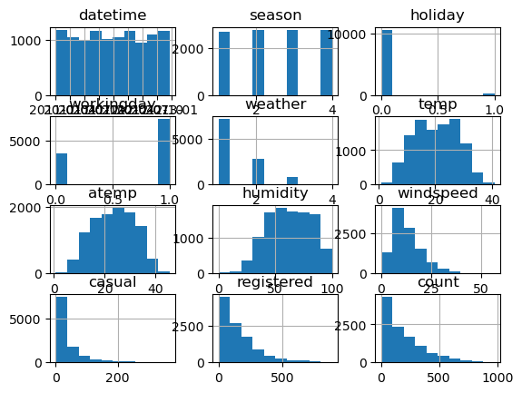

```python
# Create a histogram of all features to show the distribution of each one relative to the data. This is part of the exploritory data analysis
train.hist()
```

```python
# create a new feature
train["hour"] = train["datetime"].dt.hour
test["hour"] = test["datetime"].dt.hour
```

## Make category types for these so models know they are not just numbers

- AutoGluon originally sees these as ints, but in reality they are int representations of a category.
- Setting the dtype to category will classify these as categories in AutoGluon.

```python
train["season"] = train["season"].astype("category")
train["weather"] = train["weather"].astype("category")
test["season"] = test["season"].astype("category")
test["weather"] = test["weather"].astype("category")
```

```python
# View are new feature
train.head()
```

|  | datetime | season | holiday | workingday | weather | temp | atemp | humidity | windspeed | casual | registered | count | hour |
| --- | --- | --- | --- | --- | --- | --- | --- | --- | --- | --- | --- | --- | --- |
| 0 | 2011-01-01 00:00:00 | 1 | 0 | 0 | 1 | 9.84 | 14.395 | 81 | 0.0 | 3 | 13 | 16 | 0 |
| 1 | 2011-01-01 01:00:00 | 1 | 0 | 0 | 1 | 9.02 | 13.635 | 80 | 0.0 | 8 | 32 | 40 | 1 |
| 2 | 2011-01-01 02:00:00 | 1 | 0 | 0 | 1 | 9.02 | 13.635 | 80 | 0.0 | 5 | 27 | 32 | 2 |
| 3 | 2011-01-01 03:00:00 | 1 | 0 | 0 | 1 | 9.84 | 14.395 | 75 | 0.0 | 3 | 10 | 13 | 3 |
| 4 | 2011-01-01 04:00:00 | 1 | 0 | 0 | 1 | 9.84 | 14.395 | 75 | 0.0 | 0 | 1 | 1 | 4 |

```
array([[<Axes: title={'center': 'datetime'}>,
        <Axes: title={'center': 'holiday'}>,
        <Axes: title={'center': 'workingday'}>],
       [<Axes: title={'center': 'temp'}>,
        <Axes: title={'center': 'atemp'}>,
        <Axes: title={'center': 'humidity'}>],
       [<Axes: title={'center': 'windspeed'}>,
        <Axes: title={'center': 'casual'}>,
        <Axes: title={'center': 'registered'}>],
       [<Axes: title={'center': 'count'}>,
        <Axes: title={'center': 'hour'}>, <Axes: >]], dtype=object)
```

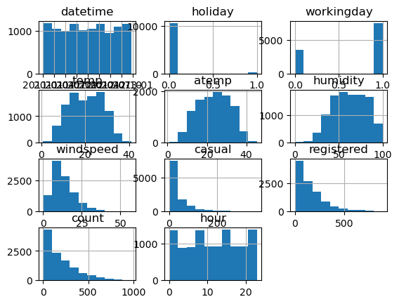

```python
# View histogram of all features again now with the hour feature
train.hist()
```

## Step 5: Rerun the model with the same settings as before, just with more features

```python
predictor_new_features = TabularPredictor(label="count", eval_metric= "root_mean_squared_error").fit(
    train_data =train.drop(["casual", "registered"], axis=1),
    time_limit = 600,
    presets = "best_quality",
    num_bag_folds = 0,           #disable bagging
    num_stack_levels = 0         #disable stacking
)
```

```
No path specified. Models will be saved in: "AutogluonModels/ag-20260712_094622"
```

```
Verbosity: 2 (Standard Logging)
```

```
=================== System Info ===================
AutoGluon Version:  1.5.0
Python Version:     3.12.13
Operating System:   Linux
Platform Machine:   x86_64
Platform Version:   #1 SMP PREEMPT_DYNAMIC Mon Jun  1 16:38:33 UTC 2026
CPU Count:          2
Pytorch Version:    2.8.0
CUDA Version:       CUDA is not available
Memory Avail:       1.05 GB / 3.74 GB (28.1%)
Disk Space Avail:   33.41 GB / 55.94 GB (59.7%)
===================================================
```

```
Presets specified: ['best_quality']
```

```
Using hyperparameters preset: hyperparameters='zeroshot'
```

```
Stack configuration (auto_stack=True): num_stack_levels=0, num_bag_folds=0, num_bag_sets=1
```

```
Beginning AutoGluon training ... Time limit = 600s
```

```
AutoGluon will save models to "/home/sagemaker-user/Bike-Sharing-Demand/project/AutogluonModels/ag-20260712_094622"
```

```
Train Data Rows:    10886
```

```
Train Data Columns: 10
```

```
Label Column:       count
```

```
AutoGluon infers your prediction problem is: 'regression' (because dtype of label-column == int and many unique label-values observed).
```

```
	Label info (max, min, mean, stddev): (977, 1, 191.57413, 181.14445)
```

```
	If 'regression' is not the correct problem_type, please manually specify the problem_type parameter during Predictor init (You may specify problem_type as one of: ['binary', 'multiclass', 'regression', 'quantile'])
```

```
Problem Type:       regression
```

```
Preprocessing data ...
```

```
Using Feature Generators to preprocess the data ...
```

```
Fitting AutoMLPipelineFeatureGenerator...
```

```
	Available Memory:                    1080.79 MB
```

```
	Train Data (Original)  Memory Usage: 0.64 MB (0.1% of available memory)
```

```
	Inferring data type of each feature based on column values. Set feature_metadata_in to manually specify special dtypes of the features.
```

```
	Stage 1 Generators:
```

```
		Fitting AsTypeFeatureGenerator...
```

```
			Note: Converting 2 features to boolean dtype as they only contain 2 unique values.
```

```
	Stage 2 Generators:
```

```
		Fitting FillNaFeatureGenerator...
```

```
	Stage 3 Generators:
```

```
		Fitting IdentityFeatureGenerator...
```

```
		Fitting CategoryFeatureGenerator...
```

```
			Fitting CategoryMemoryMinimizeFeatureGenerator...
```

```
		Fitting DatetimeFeatureGenerator...
```

```
	Stage 4 Generators:
```

```
		Fitting DropUniqueFeatureGenerator...
```

```
	Stage 5 Generators:
```

```
		Fitting DropDuplicatesFeatureGenerator...
```

```
	Types of features in original data (raw dtype, special dtypes):
```

```
		('category', []) : 2 | ['season', 'weather']
```

```
		('datetime', []) : 1 | ['datetime']
```

```
		('float', [])    : 3 | ['temp', 'atemp', 'windspeed']
```

```
		('int', [])      : 4 | ['holiday', 'workingday', 'humidity', 'hour']
```

```
	Types of features in processed data (raw dtype, special dtypes):
```

```
		('category', [])             : 2 | ['season', 'weather']
```

```
		('float', [])                : 3 | ['temp', 'atemp', 'windspeed']
```

```
		('int', [])                  : 2 | ['humidity', 'hour']
```

```
		('int', ['bool'])            : 2 | ['holiday', 'workingday']
```

```
		('int', ['datetime_as_int']) : 5 | ['datetime', 'datetime.year', 'datetime.month', 'datetime.day', 'datetime.dayofweek']
```

```
	0.1s = Fit runtime
```

```
	10 features in original data used to generate 14 features in processed data.
```

```
	Train Data (Processed) Memory Usage: 0.83 MB (0.1% of available memory)
```

```
Data preprocessing and feature engineering runtime = 0.16s ...
```

```
AutoGluon will gauge predictive performance using evaluation metric: 'root_mean_squared_error'
```

```
	This metric's sign has been flipped to adhere to being higher_is_better. The metric score can be multiplied by -1 to get the metric value.
```

```
	To change this, specify the eval_metric parameter of Predictor()
```

```
Automatically generating train/validation split with holdout_frac=0.1, Train Rows: 9797, Val Rows: 1089
```

```
Large model count detected (110 configs) ... Only displaying the first 3 models of each family. To see all, set `verbosity=3`.
User-specified model hyperparameters to be fit:
{
	'NN_TORCH': [{}, {'activation': 'elu', 'dropout_prob': 0.10077639529843717, 'hidden_size': 108, 'learning_rate': 0.002735937344002146, 'num_layers': 4, 'use_batchnorm': True, 'weight_decay': 1.356433327634438e-12, 'ag_args': {'name_suffix': '_r79', 'priority': -2}}, {'activation': 'elu', 'dropout_p…
	'GBM': [{'extra_trees': True, 'ag_args': {'name_suffix': 'XT'}}, {}, {'learning_rate': 0.03, 'num_leaves': 128, 'feature_fraction': 0.9, 'min_data_in_leaf': 3, 'ag_args': {'name_suffix': 'Large', 'priority': 0, 'hyperparameter_tune_kwargs': None}}],
	'CAT': [{}, {'depth': 6, 'grow_policy': 'SymmetricTree', 'l2_leaf_reg': 2.1542798306067823, 'learning_rate': 0.06864209415792857, 'max_ctr_complexity': 4, 'one_hot_max_size': 10, 'ag_args': {'name_suffix': '_r177', 'priority': -1}}, {'depth': 8, 'grow_policy': 'Depthwise', 'l2_leaf_reg': 2.79979995…
	'XGB': [{}, {'colsample_bytree': 0.6917311125174739, 'enable_categorical': False, 'learning_rate': 0.018063876087523967, 'max_depth': 10, 'min_child_weight': 0.6028633586934382, 'ag_args': {'name_suffix': '_r33', 'priority': -8}}, {'colsample_bytree': 0.6628423832084077, 'enable_categorical': False…
	'FASTAI': [{}, {'bs': 256, 'emb_drop': 0.5411770367537934, 'epochs': 43, 'layers': [800, 400], 'lr': 0.01519848858318159, 'ps': 0.23782946566604385, 'ag_args': {'name_suffix': '_r191', 'priority': -4}}, {'bs': 2048, 'emb_drop': 0.05070411322605811, 'epochs': 29, 'layers': [200, 100], 'lr': 0.089742…
	'RF': [{'criterion': 'gini', 'ag_args': {'name_suffix': 'Gini', 'problem_types': ['binary', 'multiclass']}}, {'criterion': 'entropy', 'ag_args': {'name_suffix': 'Entr', 'problem_types': ['binary', 'multiclass']}}, {'criterion': 'squared_error', 'ag_args': {'name_suffix': 'MSE', 'problem_types': ['r…
	'XT': [{'criterion': 'gini', 'ag_args': {'name_suffix': 'Gini', 'problem_types': ['binary', 'multiclass']}}, {'criterion': 'entropy', 'ag_args': {'name_suffix': 'Entr', 'problem_types': ['binary', 'multiclass']}}, {'criterion': 'squared_error', 'ag_args': {'name_suffix': 'MSE', 'problem_types': ['r…
}
```

```
Fitting 106 L1 models, fit_strategy="sequential" ...
```

```
Fitting model: LightGBMXT ... Training model for up to 599.84s of the 599.83s of remaining time.
```

```
	Fitting with cpus=1, gpus=0, mem=0.0/1.1 GB
```

```
[1000]	valid_set's rmse: 37.8638
```

```
[2000]	valid_set's rmse: 36.2312
```

```
[3000]	valid_set's rmse: 35.8762
```

```
[4000]	valid_set's rmse: 35.7948
```

```
[5000]	valid_set's rmse: 35.7208
```

```
[6000]	valid_set's rmse: 35.7699
```

```
	-35.712	 = Validation score   (-root_mean_squared_error)
```

```
	7.14s	 = Training   runtime
```

```
	0.72s	 = Validation runtime
```

```
Fitting model: LightGBM ... Training model for up to 591.43s of the 591.43s of remaining time.
```

```
	Fitting with cpus=1, gpus=0, mem=0.0/1.1 GB
```

```
[1000]	valid_set's rmse: 35.1998
```

```
	-35.1309	 = Validation score   (-root_mean_squared_error)
```

```
	1.87s	 = Training   runtime
```

```
	0.11s	 = Validation runtime
```

```
Fitting model: RandomForestMSE ... Training model for up to 589.34s of the 589.34s of remaining time.
```

```
	Fitting with cpus=2, gpus=0, mem=0.0/1.1 GB
```

```
	-38.6474	 = Validation score   (-root_mean_squared_error)
```

```
	14.81s	 = Training   runtime
```

```
	0.16s	 = Validation runtime
```

```
Fitting model: CatBoost ... Training model for up to 573.59s of the 573.58s of remaining time.
```

```
	Fitting with cpus=1, gpus=0
```

```
	-35.2109	 = Validation score   (-root_mean_squared_error)
```

```
	164.65s	 = Training   runtime
```

```
	0.02s	 = Validation runtime
```

```
Fitting model: ExtraTreesMSE ... Training model for up to 408.87s of the 408.87s of remaining time.
```

```
	Fitting with cpus=2, gpus=0, mem=0.0/1.1 GB
```

```
	-39.7595	 = Validation score   (-root_mean_squared_error)
```

```
	7.26s	 = Training   runtime
```

```
	0.16s	 = Validation runtime
```

```
Fitting model: NeuralNetFastAI ... Training model for up to 400.82s of the 400.82s of remaining time.
```

```
	Fitting with cpus=1, gpus=0, mem=0.0/1.0 GB
```

```
	-45.2275	 = Validation score   (-root_mean_squared_error)
```

```
	11.89s	 = Training   runtime
```

```
	0.03s	 = Validation runtime
```

```
Fitting model: XGBoost ... Training model for up to 388.88s of the 388.87s of remaining time.
```

```
	Fitting with cpus=1, gpus=0
```

```
	-35.2467	 = Validation score   (-root_mean_squared_error)
```

```
	3.24s	 = Training   runtime
```

```
	0.11s	 = Validation runtime
```

```
Fitting model: NeuralNetTorch ... Training model for up to 385.50s of the 385.50s of remaining time.
```

```
	Fitting with cpus=1, gpus=0, mem=0.0/1.1 GB
```

```
	-38.5004	 = Validation score   (-root_mean_squared_error)
```

```
	173.59s	 = Training   runtime
```

```
	0.01s	 = Validation runtime
```

```
Fitting model: LightGBMLarge ... Training model for up to 211.89s of the 211.88s of remaining time.
```

```
	Fitting with cpus=1, gpus=0, mem=0.1/1.1 GB
```

```
[1000]	valid_set's rmse: 33.3749
```

```
	-33.3333	 = Validation score   (-root_mean_squared_error)
```

```
	2.52s	 = Training   runtime
```

```
	0.13s	 = Validation runtime
```

```
Fitting model: CatBoost_r177 ... Training model for up to 208.92s of the 208.92s of remaining time.
```

```
	Fitting with cpus=1, gpus=0
```

```
	-35.5936	 = Validation score   (-root_mean_squared_error)
```

```
	46.47s	 = Training   runtime
```

```
	0.01s	 = Validation runtime
```

```
Fitting model: NeuralNetTorch_r79 ... Training model for up to 162.43s of the 162.42s of remaining time.
```

```
	Fitting with cpus=1, gpus=0, mem=0.0/1.1 GB
```

```
	-47.6037	 = Validation score   (-root_mean_squared_error)
```

```
	93.14s	 = Training   runtime
```

```
	0.01s	 = Validation runtime
```

```
Fitting model: LightGBM_r131 ... Training model for up to 69.26s of the 69.25s of remaining time.
```

```
	Fitting with cpus=1, gpus=0, mem=0.0/1.1 GB
```

```
[1000]	valid_set's rmse: 35.7279
```

```
[2000]	valid_set's rmse: 34.9346
```

```
[3000]	valid_set's rmse: 34.8671
```

```
	-34.8182	 = Validation score   (-root_mean_squared_error)
```

```
	4.5s	 = Training   runtime
```

```
	0.38s	 = Validation runtime
```

```
Fitting model: NeuralNetFastAI_r191 ... Training model for up to 63.92s of the 63.91s of remaining time.
```

```
	Fitting with cpus=1, gpus=0, mem=0.0/1.1 GB
```

```
	-43.1707	 = Validation score   (-root_mean_squared_error)
```

```
	37.03s	 = Training   runtime
```

```
	0.03s	 = Validation runtime
```

```
Fitting model: CatBoost_r9 ... Training model for up to 26.83s of the 26.83s of remaining time.
```

```
	Fitting with cpus=1, gpus=0
```

```
	Ran out of time, early stopping on iteration 1463.
```

```
	-34.8869	 = Validation score   (-root_mean_squared_error)
```

```
	27.25s	 = Training   runtime
```

```
	0.04s	 = Validation runtime
```

```
Fitting model: WeightedEnsemble_L2 ... Training model for up to 360.00s of the -0.64s of remaining time.
```

```
	Fitting 1 model on all data | Fitting with cpus=2, gpus=0, mem=0.0/1.1 GB
```

```
	Ensemble Weights: {'LightGBMLarge': 0.5, 'XGBoost': 0.182, 'NeuralNetTorch': 0.182, 'CatBoost': 0.091, 'NeuralNetTorch_r79': 0.045}
```

```
	-32.2423	 = Validation score   (-root_mean_squared_error)
```

```
	0.02s	 = Training   runtime
```

```
	0.0s	 = Validation runtime
```

```
AutoGluon training complete, total runtime = 600.69s ... Best model: WeightedEnsemble_L2 | Estimated inference throughput: 3784.6 rows/s (1089 batch size)
```

```
TabularPredictor saved. To load, use: predictor = TabularPredictor.load("/home/sagemaker-user/Bike-Sharing-Demand/project/AutogluonModels/ag-20260712_094622")
```

```python
predictor_new_features.fit_summary()
```

```
*** Summary of fit() ***
Estimated performance of each model:
                   model  score_val              eval_metric  pred_time_val    fit_time  pred_time_val_marginal  fit_time_marginal  stack_level  can_infer  fit_order
0    WeightedEnsemble_L2 -32.242313  root_mean_squared_error       0.287742  437.170328                0.001242           0.022660            2       True         15
1          LightGBMLarge -33.333302  root_mean_squared_error       0.131894    2.523003                0.131894           2.523003            1       True          9
2          LightGBM_r131 -34.818175  root_mean_squared_error       0.377498    4.497118                0.377498           4.497118            1       True         12
3            CatBoost_r9 -34.886934  root_mean_squared_error       0.044526   27.248724                0.044526          27.248724            1       True         14
4               LightGBM -35.130899  root_mean_squared_error       0.105706    1.871495                0.105706           1.871495            1       True          2
5               CatBoost -35.210942  root_mean_squared_error       0.023075  164.651799                0.023075         164.651799            1       True          4
6                XGBoost -35.246729  root_mean_squared_error       0.105333    3.235746                0.105333           3.235746            1       True          7
7          CatBoost_r177 -35.593642  root_mean_squared_error       0.009993   46.468049                0.009993          46.468049            1       True         10
8             LightGBMXT -35.712042  root_mean_squared_error       0.724674    7.141032                0.724674           7.141032            1       True          1
9         NeuralNetTorch -38.500403  root_mean_squared_error       0.012635  173.593198                0.012635         173.593198            1       True          8
10       RandomForestMSE -38.647406  root_mean_squared_error       0.159413   14.812331                0.159413          14.812331            1       True          3
11         ExtraTreesMSE -39.759523  root_mean_squared_error       0.159490    7.263957                0.159490           7.263957            1       True          5
12  NeuralNetFastAI_r191 -43.170731  root_mean_squared_error       0.030920   37.031133                0.030920          37.031133            1       True         13
13       NeuralNetFastAI -45.227535  root_mean_squared_error       0.033075   11.890065                0.033075          11.890065            1       True          6
14    NeuralNetTorch_r79 -47.603685  root_mean_squared_error       0.013563   93.143922                0.013563          93.143922            1       True         11
Number of models trained: 15
Types of models trained:
{'RFModel', 'CatBoostModel', 'XTModel', 'NNFastAiTabularModel', 'WeightedEnsembleModel', 'LGBModel', 'TabularNeuralNetTorchModel', 'XGBoostModel'}
Bagging used: False
Multi-layer stack-ensembling used: False
Feature Metadata (Processed):
(raw dtype, special dtypes):
('category', [])             : 2 | ['season', 'weather']
('float', [])                : 3 | ['temp', 'atemp', 'windspeed']
('int', [])                  : 2 | ['humidity', 'hour']
('int', ['bool'])            : 2 | ['holiday', 'workingday']
('int', ['datetime_as_int']) : 5 | ['datetime', 'datetime.year', 'datetime.month', 'datetime.day', 'datetime.dayofweek']
*** End of fit() summary ***
```

```
{'model_types': {'LightGBMXT': 'LGBModel',
  'LightGBM': 'LGBModel',
  'RandomForestMSE': 'RFModel',
  'CatBoost': 'CatBoostModel',
  'ExtraTreesMSE': 'XTModel',
  'NeuralNetFastAI': 'NNFastAiTabularModel',
  'XGBoost': 'XGBoostModel',
  'NeuralNetTorch': 'TabularNeuralNetTorchModel',
  'LightGBMLarge': 'LGBModel',
  'CatBoost_r177': 'CatBoostModel',
  'NeuralNetTorch_r79': 'TabularNeuralNetTorchModel',
  'LightGBM_r131': 'LGBModel',
  'NeuralNetFastAI_r191': 'NNFastAiTabularModel',
  'CatBoost_r9': 'CatBoostModel',
  'WeightedEnsemble_L2': 'WeightedEnsembleModel'},
 'model_performance': {'LightGBMXT': -35.712041801962215,
  'LightGBM': -35.13089877167801,
  'RandomForestMSE': -38.647406010339566,
  'CatBoost': -35.21094228573219,
  'ExtraTreesMSE': -39.759523375526086,
  'NeuralNetFastAI': -45.22753495731008,
  'XGBoost': -35.24672900170408,
  'NeuralNetTorch': -38.50040333192168,
  'LightGBMLarge': -33.333302384436955,
  'CatBoost_r177': -35.59364188982808,
  'NeuralNetTorch_r79': -47.60368537549225,
  'LightGBM_r131': -34.81817497258195,
  'NeuralNetFastAI_r191': -43.170731021795916,
  'CatBoost_r9': -34.886933847650084,
  'WeightedEnsemble_L2': -32.242312674891544},
 'model_best': 'WeightedEnsemble_L2',
 'model_paths': {'LightGBMXT': ['LightGBMXT'],
  'LightGBM': ['LightGBM'],
  'RandomForestMSE': ['RandomForestMSE'],
  'CatBoost': ['CatBoost'],
  'ExtraTreesMSE': ['ExtraTreesMSE'],
  'NeuralNetFastAI': ['NeuralNetFastAI'],
  'XGBoost': ['XGBoost'],
  'NeuralNetTorch': ['NeuralNetTorch'],
  'LightGBMLarge': ['LightGBMLarge'],
```

[output cut: 208 more lines]

```
 0        True         15
 1        True          9
 2        True         12
 3        True         14
 4        True          2
 5        True          4
 6        True          7
 7        True         10
 8        True          1
 9        True          8
 10       True          3
 11       True          5
 12       True         13
 13       True          6
 14       True         11  }
```

```python
# Describe predictions to check whether there are negative values
predictions_new_features = predictor_new_features.predict(test)
predictions_new_features.describe()
```

```
count    6493.000000
mean      192.289658
std       172.607803
min       -12.742237
25%        46.498840
50%       153.633240
75%       284.973785
max       893.337036
Name: count, dtype: float64
```

```python
# Number of negative values
neg_count = (predictions_new_features < 0)
neg_count.sum()
```

```
80
```

```python
predictions_new_features[predictions_new_features < 0] = 0
```

```python
# Same submitting predictions
submission_new_features = submission
submission_new_features["count"] = predictions_new_features
submission_new_features.to_csv("submission_new_features.csv", index=False)
```

```python
!kaggle competitions submit -c bike-sharing-demand -f submission_new_features.csv -m "new features"
```

```
Successfully submitted to Bike Sharing Demand
```

```python
!kaggle competitions submissions -c bike-sharing-demand | tail -n +1 | head -n 6
```

```
     ref  fileName                         date                        description                            status                     publicScore  privateScore
--------  -------------------------------  --------------------------  -------------------------------------  -------------------------  -----------  ------------
54603743  submission_new_features.csv      2026-07-12 10:03:37.907000  new features                           SubmissionStatus.COMPLETE  0.51764      0.51764
54603261  submission.csv                   2026-07-12 09:45:21.107000  first raw submission                   SubmissionStatus.COMPLETE  1.41288      1.41288
54580832  submission_hpo_new_features.csv  2026-07-11 17:45:33.997000  hpo with more features                 SubmissionStatus.COMPLETE  0.51575      0.51575
54533020  submission_more_feat.csv         2026-07-10 15:56:29.397000  more features                          SubmissionStatus.COMPLETE  0.50205      0.50205
```

```
tail: write error: Broken pipe
```

#### New Score of `0.51764`

## Step 6: Hyper parameter optimization

- There are many options for hyper parameter optimization.
- Options are to change the AutoGluon higher level parameters or the individual model hyperparameters.
- The hyperparameters of the models themselves that are in AutoGluon. Those need the `hyperparameter` and `hyperparameter_tune_kwargs` arguments.

```python
hyperparameters = {
    'GBM': {
        'num_boost_round': 3000,
        'num_leaves': 100,
        'learning_rate': 0.05
    },
    'CAT': {
        'iterations': 10000,
        'learning_rate': 0.05,
        'depth': 10
    },
    'XGB': {
        'n_estimators': 10000,
        'max_depth': 10,
        'learning_rate': 0.05
    },
}

hyperparameter_tune_kwargs = {
    'scheduler': 'local',
    'searcher': 'auto'
}

predictor_new_hpo = TabularPredictor(label="count", eval_metric= "root_mean_squared_error").fit(
    train_data = train.drop(["casual", "registered"], axis=1),
    time_limit = 600,
    presets = "best_quality",
    num_bag_folds = 0,
    num_stack_levels = 0,
    hyperparameters = hyperparameters,
    hyperparameter_tune_kwargs = hyperparameter_tune_kwargs
)
```

```
No path specified. Models will be saved in: "AutogluonModels/ag-20260712_100357"
```

```
Verbosity: 2 (Standard Logging)
```

```
=================== System Info ===================
AutoGluon Version:  1.5.0
Python Version:     3.12.13
Operating System:   Linux
Platform Machine:   x86_64
Platform Version:   #1 SMP PREEMPT_DYNAMIC Mon Jun  1 16:38:33 UTC 2026
CPU Count:          2
Pytorch Version:    2.8.0
CUDA Version:       CUDA is not available
Memory Avail:       1.01 GB / 3.74 GB (26.9%)
Disk Space Avail:   32.87 GB / 55.94 GB (58.8%)
===================================================
```

```
Presets specified: ['best_quality']
```

```
Stack configuration (auto_stack=True): num_stack_levels=0, num_bag_folds=0, num_bag_sets=1
```

```
Beginning AutoGluon training ... Time limit = 600s
```

```
AutoGluon will save models to "/home/sagemaker-user/Bike-Sharing-Demand/project/AutogluonModels/ag-20260712_100357"
```

```
Train Data Rows:    10886
```

```
Train Data Columns: 10
```

```
Label Column:       count
```

```
AutoGluon infers your prediction problem is: 'regression' (because dtype of label-column == int and many unique label-values observed).
```

```
	Label info (max, min, mean, stddev): (977, 1, 191.57413, 181.14445)
```

```
	If 'regression' is not the correct problem_type, please manually specify the problem_type parameter during Predictor init (You may specify problem_type as one of: ['binary', 'multiclass', 'regression', 'quantile'])
```

```
Problem Type:       regression
```

```
Preprocessing data ...
```

```
Using Feature Generators to preprocess the data ...
```

```
Fitting AutoMLPipelineFeatureGenerator...
```

```
	Available Memory:                    1031.36 MB
```

```
	Train Data (Original)  Memory Usage: 0.64 MB (0.1% of available memory)
```

```
	Inferring data type of each feature based on column values. Set feature_metadata_in to manually specify special dtypes of the features.
```

```
	Stage 1 Generators:
```

```
		Fitting AsTypeFeatureGenerator...
```

```
			Note: Converting 2 features to boolean dtype as they only contain 2 unique values.
```

```
	Stage 2 Generators:
```

```
		Fitting FillNaFeatureGenerator...
```

```
	Stage 3 Generators:
```

```
		Fitting IdentityFeatureGenerator...
```

```
		Fitting CategoryFeatureGenerator...
```

```
			Fitting CategoryMemoryMinimizeFeatureGenerator...
```

```
		Fitting DatetimeFeatureGenerator...
```

```
	Stage 4 Generators:
```

```
		Fitting DropUniqueFeatureGenerator...
```

```
	Stage 5 Generators:
```

```
		Fitting DropDuplicatesFeatureGenerator...
```

```
	Types of features in original data (raw dtype, special dtypes):
```

```
		('category', []) : 2 | ['season', 'weather']
```

```
		('datetime', []) : 1 | ['datetime']
```

```
		('float', [])    : 3 | ['temp', 'atemp', 'windspeed']
```

```
		('int', [])      : 4 | ['holiday', 'workingday', 'humidity', 'hour']
```

```
	Types of features in processed data (raw dtype, special dtypes):
```

```
		('category', [])             : 2 | ['season', 'weather']
```

```
		('float', [])                : 3 | ['temp', 'atemp', 'windspeed']
```

```
		('int', [])                  : 2 | ['humidity', 'hour']
```

```
		('int', ['bool'])            : 2 | ['holiday', 'workingday']
```

```
		('int', ['datetime_as_int']) : 5 | ['datetime', 'datetime.year', 'datetime.month', 'datetime.day', 'datetime.dayofweek']
```

```
	0.1s = Fit runtime
```

```
	10 features in original data used to generate 14 features in processed data.
```

```
	Train Data (Processed) Memory Usage: 0.83 MB (0.1% of available memory)
```

```
Data preprocessing and feature engineering runtime = 0.15s ...
```

```
AutoGluon will gauge predictive performance using evaluation metric: 'root_mean_squared_error'
```

```
	This metric's sign has been flipped to adhere to being higher_is_better. The metric score can be multiplied by -1 to get the metric value.
```

```
	To change this, specify the eval_metric parameter of Predictor()
```

```
Automatically generating train/validation split with holdout_frac=0.2, Train Rows: 8708, Val Rows: 2178
```

```
User-specified model hyperparameters to be fit:
{
	'GBM': [{'num_boost_round': 3000, 'num_leaves': 100, 'learning_rate': 0.05}],
	'CAT': [{'iterations': 10000, 'learning_rate': 0.05, 'depth': 10}],
	'XGB': [{'n_estimators': 10000, 'max_depth': 10, 'learning_rate': 0.05}],
}
```

```
Fitting 3 L1 models, fit_strategy="sequential" ...
```

```
Hyperparameter tuning model: LightGBM ... Tuning model for up to 179.95s of the 599.84s of remaining time.
```

```
[1000]	valid_set's rmse: 36.6629
```

```
[1000]	valid_set's rmse: 35.974
```

```
[1000]	valid_set's rmse: 35.6087
```

```
	Stopping HPO to satisfy time limit...
```

```
Fitted model: LightGBM/T1 ...
```

```
	-35.5651	 = Validation score   (-root_mean_squared_error)
```

```
	2.33s	 = Training   runtime
```

```
	0.39s	 = Validation runtime
```

```
Fitted model: LightGBM/T2 ...
```

```
	-36.3425	 = Validation score   (-root_mean_squared_error)
```

```
	2.01s	 = Training   runtime
```

```
	0.17s	 = Validation runtime
```

```
Fitted model: LightGBM/T3 ...
```

```
	-35.2064	 = Validation score   (-root_mean_squared_error)
```

```
	1.79s	 = Training   runtime
```

```
	0.15s	 = Validation runtime
```

```
Fitted model: LightGBM/T4 ...
```

```
	-35.6883	 = Validation score   (-root_mean_squared_error)
```

```
	1.68s	 = Training   runtime
```

```
	0.14s	 = Validation runtime
```

```
Fitted model: LightGBM/T5 ...
```

```
	-36.3454	 = Validation score   (-root_mean_squared_error)
```

```
	1.61s	 = Training   runtime
```

```
	0.1s	 = Validation runtime
```

```
Fitted model: LightGBM/T6 ...
```

```
	-35.5863	 = Validation score   (-root_mean_squared_error)
```

```
	1.9s	 = Training   runtime
```

```
	0.22s	 = Validation runtime
```

```
Fitted model: LightGBM/T7 ...
```

```
	-36.5808	 = Validation score   (-root_mean_squared_error)
```

```
	2.95s	 = Training   runtime
```

```
	0.43s	 = Validation runtime
```

```
Fitted model: LightGBM/T8 ...
```

```
	-36.0142	 = Validation score   (-root_mean_squared_error)
```

```
	2.08s	 = Training   runtime
```

```
	0.28s	 = Validation runtime
```

```
Fitted model: LightGBM/T9 ...
```

```
	-35.5863	 = Validation score   (-root_mean_squared_error)
```

```
	1.84s	 = Training   runtime
```

```
	0.25s	 = Validation runtime
```

```
Fitted model: LightGBM/T10 ...
```

```
	-35.4959	 = Validation score   (-root_mean_squared_error)
```

```
	1.8s	 = Training   runtime
```

```
	0.24s	 = Validation runtime
```

```
Fitted model: LightGBM/T11 ...
```

```
	-36.0411	 = Validation score   (-root_mean_squared_error)
```

```
	1.43s	 = Training   runtime
```

```
	0.1s	 = Validation runtime
```

```
Fitted model: LightGBM/T12 ...
```

```
	-35.8961	 = Validation score   (-root_mean_squared_error)
```

```
	1.99s	 = Training   runtime
```

```
	0.25s	 = Validation runtime
```

```
Fitted model: LightGBM/T13 ...
```

```
	-36.1985	 = Validation score   (-root_mean_squared_error)
```

```
	1.62s	 = Training   runtime
```

```
	0.13s	 = Validation runtime
```

```
Fitted model: LightGBM/T14 ...
```

```
	-35.5651	 = Validation score   (-root_mean_squared_error)
```

```
	1.77s	 = Training   runtime
```

```
	0.2s	 = Validation runtime
```

```
Fitted model: LightGBM/T15 ...
```

```
	-36.0688	 = Validation score   (-root_mean_squared_error)
```

```
	1.87s	 = Training   runtime
```

```
	0.19s	 = Validation runtime
```

```
Fitted model: LightGBM/T16 ...
```

```
	-35.8566	 = Validation score   (-root_mean_squared_error)
```

```
	1.78s	 = Training   runtime
```

```
	0.2s	 = Validation runtime
```

```
Fitted model: LightGBM/T17 ...
```

```
	-36.5396	 = Validation score   (-root_mean_squared_error)
```

```
	1.65s	 = Training   runtime
```

```
	0.1s	 = Validation runtime
```

```
Fitted model: LightGBM/T18 ...
```

```
	-35.5744	 = Validation score   (-root_mean_squared_error)
```

```
	1.53s	 = Training   runtime
```

```
	0.11s	 = Validation runtime
```

```
Fitted model: LightGBM/T19 ...
```

```
	-36.315	 = Validation score   (-root_mean_squared_error)
```

```
	1.6s	 = Training   runtime
```

```
	0.15s	 = Validation runtime
```

```
Fitted model: LightGBM/T20 ...
```

```
	-35.9365	 = Validation score   (-root_mean_squared_error)
```

```
	1.79s	 = Training   runtime
```

```
	0.18s	 = Validation runtime
```

```
Fitted model: LightGBM/T21 ...
```

```
	-36.1498	 = Validation score   (-root_mean_squared_error)
```

```
	1.7s	 = Training   runtime
```

```
	0.23s	 = Validation runtime
```

```
Fitted model: LightGBM/T22 ...
```

```
	-35.8523	 = Validation score   (-root_mean_squared_error)
```

```
	1.73s	 = Training   runtime
```

```
	0.14s	 = Validation runtime
```

```
Fitted model: LightGBM/T23 ...
```

```
	-36.2722	 = Validation score   (-root_mean_squared_error)
```

```
	1.85s	 = Training   runtime
```

```
	0.15s	 = Validation runtime
```

```
Fitted model: LightGBM/T24 ...
```

```
	-36.367	 = Validation score   (-root_mean_squared_error)
```

```
	1.83s	 = Training   runtime
```

```
	0.19s	 = Validation runtime
```

```
Fitted model: LightGBM/T25 ...
```

```
	-36.2939	 = Validation score   (-root_mean_squared_error)
```

```
	1.77s	 = Training   runtime
```

```
	0.17s	 = Validation runtime
```

```
Fitted model: LightGBM/T26 ...
```

```
	-36.2383	 = Validation score   (-root_mean_squared_error)
```

```
	1.4s	 = Training   runtime
```

```
	0.08s	 = Validation runtime
```

```
Fitted model: LightGBM/T27 ...
```

```
	-36.6927	 = Validation score   (-root_mean_squared_error)
```

```
	2.41s	 = Training   runtime
```

```
	0.33s	 = Validation runtime
```

```
Fitted model: LightGBM/T28 ...
```

```
	-35.5167	 = Validation score   (-root_mean_squared_error)
```

```
	1.71s	 = Training   runtime
```

```
	0.34s	 = Validation runtime
```

```
Fitted model: LightGBM/T29 ...
```

```
	-36.3713	 = Validation score   (-root_mean_squared_error)
```

```
	3.79s	 = Training   runtime
```

```
	0.21s	 = Validation runtime
```

```
Fitted model: LightGBM/T30 ...
```

```
	-36.334	 = Validation score   (-root_mean_squared_error)
```

```
	2.3s	 = Training   runtime
```

```
	0.24s	 = Validation runtime
```

```
Fitted model: LightGBM/T31 ...
```

```
	-36.4769	 = Validation score   (-root_mean_squared_error)
```

```
	2.35s	 = Training   runtime
```

```
	0.25s	 = Validation runtime
```

```
Fitted model: LightGBM/T32 ...
```

```
	-36.2722	 = Validation score   (-root_mean_squared_error)
```

```
	1.86s	 = Training   runtime
```

```
	0.15s	 = Validation runtime
```

```
Fitted model: LightGBM/T33 ...
```

```
	-36.3425	 = Validation score   (-root_mean_squared_error)
```

```
	1.84s	 = Training   runtime
```

```
	0.17s	 = Validation runtime
```

```
Fitted model: LightGBM/T34 ...
```

```
	-36.6721	 = Validation score   (-root_mean_squared_error)
```

```
	1.75s	 = Training   runtime
```

```
	0.14s	 = Validation runtime
```

```
Fitted model: LightGBM/T35 ...
```

```
	-36.2383	 = Validation score   (-root_mean_squared_error)
```

```
	1.45s	 = Training   runtime
```

```
	0.08s	 = Validation runtime
```

```
Fitted model: LightGBM/T36 ...
```

```
	-36.6393	 = Validation score   (-root_mean_squared_error)
```

```
	2.18s	 = Training   runtime
```

```
	0.25s	 = Validation runtime
```

```
Fitted model: LightGBM/T37 ...
```

```
	-35.8457	 = Validation score   (-root_mean_squared_error)
```

```
	1.8s	 = Training   runtime
```

```
	0.17s	 = Validation runtime
```

```
Fitted model: LightGBM/T38 ...
```

```
	-36.2145	 = Validation score   (-root_mean_squared_error)
```

```
	2.18s	 = Training   runtime
```

```
	0.25s	 = Validation runtime
```

```
Fitted model: LightGBM/T39 ...
```

```
	-36.0642	 = Validation score   (-root_mean_squared_error)
```

```
	2.01s	 = Training   runtime
```

```
	0.27s	 = Validation runtime
```

```
Fitted model: LightGBM/T40 ...
```

```
	-36.1258	 = Validation score   (-root_mean_squared_error)
```

```
	2.41s	 = Training   runtime
```

```
	0.33s	 = Validation runtime
```

```
Fitted model: LightGBM/T41 ...
```

```
	-36.2303	 = Validation score   (-root_mean_squared_error)
```

```
	1.5s	 = Training   runtime
```

```
	0.09s	 = Validation runtime
```

```
Fitted model: LightGBM/T42 ...
```

```
	-36.651	 = Validation score   (-root_mean_squared_error)
```

```
	1.77s	 = Training   runtime
```

```
	0.14s	 = Validation runtime
```

```
Fitted model: LightGBM/T43 ...
```

```
	-36.0167	 = Validation score   (-root_mean_squared_error)
```

```
	1.7s	 = Training   runtime
```

```
	0.14s	 = Validation runtime
```

```
Fitted model: LightGBM/T44 ...
```

```
	-35.8513	 = Validation score   (-root_mean_squared_error)
```

```
	1.92s	 = Training   runtime
```

```
	0.22s	 = Validation runtime
```

```
Fitted model: LightGBM/T45 ...
```

```
	-35.5249	 = Validation score   (-root_mean_squared_error)
```

```
	1.84s	 = Training   runtime
```

```
	0.19s	 = Validation runtime
```

```
Fitted model: LightGBM/T46 ...
```

```
	-36.3454	 = Validation score   (-root_mean_squared_error)
```

```
	1.53s	 = Training   runtime
```

```
	0.1s	 = Validation runtime
```

```
Fitted model: LightGBM/T47 ...
```

```
	-35.9751	 = Validation score   (-root_mean_squared_error)
```

```
	1.6s	 = Training   runtime
```

```
	0.13s	 = Validation runtime
```

```
Fitted model: LightGBM/T48 ...
```

```
	-35.9776	 = Validation score   (-root_mean_squared_error)
```

```
	1.79s	 = Training   runtime
```

```
	0.12s	 = Validation runtime
```

```
Fitted model: LightGBM/T49 ...
```

```
	-36.0138	 = Validation score   (-root_mean_squared_error)
```

```
	1.57s	 = Training   runtime
```

```
	0.09s	 = Validation runtime
```

```
Fitted model: LightGBM/T50 ...
```

```
	-36.2722	 = Validation score   (-root_mean_squared_error)
```

```
	1.77s	 = Training   runtime
```

```
	0.16s	 = Validation runtime
```

```
Fitted model: LightGBM/T51 ...
```

```
	-36.4185	 = Validation score   (-root_mean_squared_error)
```

```
	2.06s	 = Training   runtime
```

```
	0.25s	 = Validation runtime
```

```
Fitted model: LightGBM/T52 ...
```

```
	-36.0529	 = Validation score   (-root_mean_squared_error)
```

```
	1.43s	 = Training   runtime
```

```
	0.1s	 = Validation runtime
```

```
Fitted model: LightGBM/T53 ...
```

```
	-36.1733	 = Validation score   (-root_mean_squared_error)
```

```
	2.23s	 = Training   runtime
```

```
	0.31s	 = Validation runtime
```

```
Fitted model: LightGBM/T54 ...
```

```
	-36.1145	 = Validation score   (-root_mean_squared_error)
```

```
	1.97s	 = Training   runtime
```

```
	0.3s	 = Validation runtime
```

```
Fitted model: LightGBM/T55 ...
```

```
	-34.9264	 = Validation score   (-root_mean_squared_error)
```

```
	2.92s	 = Training   runtime
```

```
	0.09s	 = Validation runtime
```

```
Fitted model: LightGBM/T56 ...
```

```
	-36.1111	 = Validation score   (-root_mean_squared_error)
```

```
	2.15s	 = Training   runtime
```

```
	0.26s	 = Validation runtime
```

```
Fitted model: LightGBM/T57 ...
```

```
	-36.3815	 = Validation score   (-root_mean_squared_error)
```

```
	2.14s	 = Training   runtime
```

```
	0.25s	 = Validation runtime
```

```
Fitted model: LightGBM/T58 ...
```

```
	-36.1974	 = Validation score   (-root_mean_squared_error)
```

```
	1.81s	 = Training   runtime
```

```
	0.17s	 = Validation runtime
```

```
Fitted model: LightGBM/T59 ...
```

```
	-36.3361	 = Validation score   (-root_mean_squared_error)
```

```
	1.44s	 = Training   runtime
```

```
	0.07s	 = Validation runtime
```

```
Fitted model: LightGBM/T60 ...
```

```
	-36.3935	 = Validation score   (-root_mean_squared_error)
```

```
	1.84s	 = Training   runtime
```

```
	0.21s	 = Validation runtime
```

```
Fitted model: LightGBM/T61 ...
```

```
	-35.904	 = Validation score   (-root_mean_squared_error)
```

```
	1.77s	 = Training   runtime
```

```
	0.18s	 = Validation runtime
```

```
Fitted model: LightGBM/T62 ...
```

```
	-35.8484	 = Validation score   (-root_mean_squared_error)
```

```
	1.85s	 = Training   runtime
```

```
	0.15s	 = Validation runtime
```

```
Fitted model: LightGBM/T63 ...
```

```
	-36.3523	 = Validation score   (-root_mean_squared_error)
```

```
	1.48s	 = Training   runtime
```

```
	0.08s	 = Validation runtime
```

```
Fitted model: LightGBM/T64 ...
```

```
	-36.0878	 = Validation score   (-root_mean_squared_error)
```

```
	1.67s	 = Training   runtime
```

```
	0.15s	 = Validation runtime
```

```
Fitted model: LightGBM/T65 ...
```

```
	-35.8283	 = Validation score   (-root_mean_squared_error)
```

```
	1.8s	 = Training   runtime
```

```
	0.18s	 = Validation runtime
```

```
Fitted model: LightGBM/T66 ...
```

```
	-35.5863	 = Validation score   (-root_mean_squared_error)
```

```
	1.8s	 = Training   runtime
```

```
	0.23s	 = Validation runtime
```

```
Fitted model: LightGBM/T67 ...
```

```
	-35.2064	 = Validation score   (-root_mean_squared_error)
```

```
	1.69s	 = Training   runtime
```

```
	0.15s	 = Validation runtime
```

```
Fitted model: LightGBM/T68 ...
```

```
	-36.8058	 = Validation score   (-root_mean_squared_error)
```

```
	1.39s	 = Training   runtime
```

```
	0.07s	 = Validation runtime
```

```
Fitted model: LightGBM/T69 ...
```

```
	-36.8486	 = Validation score   (-root_mean_squared_error)
```

```
	1.68s	 = Training   runtime
```

```
	0.13s	 = Validation runtime
```

```
Fitted model: LightGBM/T70 ...
```

```
	-36.0136	 = Validation score   (-root_mean_squared_error)
```

```
	1.7s	 = Training   runtime
```

```
	0.16s	 = Validation runtime
```

```
Fitted model: LightGBM/T71 ...
```

```
	-35.5831	 = Validation score   (-root_mean_squared_error)
```

```
	2.07s	 = Training   runtime
```

```
	0.23s	 = Validation runtime
```

```
Fitted model: LightGBM/T72 ...
```

```
	-35.2064	 = Validation score   (-root_mean_squared_error)
```

```
	1.81s	 = Training   runtime
```

```
	0.15s	 = Validation runtime
```

```
Fitted model: LightGBM/T73 ...
```

```
	-35.3696	 = Validation score   (-root_mean_squared_error)
```

```
	1.44s	 = Training   runtime
```

```
	0.12s	 = Validation runtime
```

```
Fitted model: LightGBM/T74 ...
```

```
	-35.6695	 = Validation score   (-root_mean_squared_error)
```

```
	1.43s	 = Training   runtime
```

```
	0.09s	 = Validation runtime
```

```
Fitted model: LightGBM/T75 ...
```

```
	-35.3782	 = Validation score   (-root_mean_squared_error)
```

```
	1.46s	 = Training   runtime
```

```
	0.09s	 = Validation runtime
```

```
Fitted model: LightGBM/T76 ...
```

```
	-36.5334	 = Validation score   (-root_mean_squared_error)
```

```
	1.66s	 = Training   runtime
```

```
	0.12s	 = Validation runtime
```

```
Fitted model: LightGBM/T77 ...
```

```
	-35.8961	 = Validation score   (-root_mean_squared_error)
```

```
	1.93s	 = Training   runtime
```

```
	0.24s	 = Validation runtime
```

```
Fitted model: LightGBM/T78 ...
```

```
	-35.706	 = Validation score   (-root_mean_squared_error)
```

```
	1.23s	 = Training   runtime
```

```
	0.06s	 = Validation runtime
```

```
Fitted model: LightGBM/T79 ...
```

```
	-35.6978	 = Validation score   (-root_mean_squared_error)
```

```
	1.89s	 = Training   runtime
```

```
	0.21s	 = Validation runtime
```

```
Fitted model: LightGBM/T80 ...
```

```
	-36.5549	 = Validation score   (-root_mean_squared_error)
```

```
	1.92s	 = Training   runtime
```

```
	0.21s	 = Validation runtime
```

```
Hyperparameter tuning model: CatBoost ... Tuning model for up to 179.95s of the 414.5s of remaining time.
```

```
	Ran out of time, early stopping on iteration 3728.
```

```
	Stopping HPO to satisfy time limit...
```

```
Fitted model: CatBoost/T1 ...
```

```
	-35.596	 = Validation score   (-root_mean_squared_error)
```

```
	47.25s	 = Training   runtime
```

```
	0.02s	 = Validation runtime
```

```
Fitted model: CatBoost/T2 ...
```

```
	-35.3503	 = Validation score   (-root_mean_squared_error)
```

```
	41.57s	 = Training   runtime
```

```
	0.02s	 = Validation runtime
```

```
Fitted model: CatBoost/T3 ...
```

```
	-35.4598	 = Validation score   (-root_mean_squared_error)
```

```
	86.08s	 = Training   runtime
```

```
	0.04s	 = Validation runtime
```

```
Hyperparameter tuning model: XGBoost ... Tuning model for up to 179.95s of the 238.6s of remaining time.
```

```
	Stopping HPO to satisfy time limit...
```

```
Fitted model: XGBoost/T1 ...
```

```
	-36.9387	 = Validation score   (-root_mean_squared_error)
```

```
	6.06s	 = Training   runtime
```

```
	0.14s	 = Validation runtime
```

```
Fitted model: XGBoost/T2 ...
```

```
	-40.0539	 = Validation score   (-root_mean_squared_error)
```

```
	5.61s	 = Training   runtime
```

```
	0.3s	 = Validation runtime
```

```
Fitted model: XGBoost/T3 ...
```

```
	-38.65	 = Validation score   (-root_mean_squared_error)
```

```
	4.51s	 = Training   runtime
```

```
	0.29s	 = Validation runtime
```

```
Fitted model: XGBoost/T4 ...
```

```
	-37.4957	 = Validation score   (-root_mean_squared_error)
```

```
	5.22s	 = Training   runtime
```

```
	0.4s	 = Validation runtime
```

```
Fitted model: XGBoost/T5 ...
```

```
	-38.3036	 = Validation score   (-root_mean_squared_error)
```

```
	4.79s	 = Training   runtime
```

```
	0.38s	 = Validation runtime
```

```
Fitted model: XGBoost/T6 ...
```

```
	-43.7254	 = Validation score   (-root_mean_squared_error)
```

```
	21.78s	 = Training   runtime
```

```
	3.7s	 = Validation runtime
```

```
Fitted model: XGBoost/T7 ...
```

```
	-37.2618	 = Validation score   (-root_mean_squared_error)
```

```
	4.62s	 = Training   runtime
```

```
	0.24s	 = Validation runtime
```

```
Fitted model: XGBoost/T8 ...
```

```
	-41.7543	 = Validation score   (-root_mean_squared_error)
```

```
	9.64s	 = Training   runtime
```

```
	0.8s	 = Validation runtime
```

```
Fitted model: XGBoost/T9 ...
```

```
	-41.8297	 = Validation score   (-root_mean_squared_error)
```

```
	8.57s	 = Training   runtime
```

```
	0.97s	 = Validation runtime
```

```
Fitted model: XGBoost/T10 ...
```

```
	-45.8447	 = Validation score   (-root_mean_squared_error)
```

```
	10.59s	 = Training   runtime
```

```
	1.4s	 = Validation runtime
```

```
Fitted model: XGBoost/T11 ...
```

```
	-39.3998	 = Validation score   (-root_mean_squared_error)
```

```
	5.94s	 = Training   runtime
```

```
	0.33s	 = Validation runtime
```

```
Fitted model: XGBoost/T12 ...
```

```
	-38.3171	 = Validation score   (-root_mean_squared_error)
```

```
	5.82s	 = Training   runtime
```

```
	0.27s	 = Validation runtime
```

```
Fitted model: XGBoost/T13 ...
```

```
	-37.8833	 = Validation score   (-root_mean_squared_error)
```

```
	5.67s	 = Training   runtime
```

```
	0.29s	 = Validation runtime
```

```
Fitted model: XGBoost/T14 ...
```

```
	-37.4957	 = Validation score   (-root_mean_squared_error)
```

```
	5.08s	 = Training   runtime
```

```
	0.4s	 = Validation runtime
```

```
Fitted model: XGBoost/T15 ...
```

```
	-39.3998	 = Validation score   (-root_mean_squared_error)
```

```
	7.21s	 = Training   runtime
```

```
	0.65s	 = Validation runtime
```

```
Fitted model: XGBoost/T16 ...
```

```
	-39.5802	 = Validation score   (-root_mean_squared_error)
```

```
	5.14s	 = Training   runtime
```

```
	0.29s	 = Validation runtime
```

```
Fitted model: XGBoost/T17 ...
```

```
	-37.2618	 = Validation score   (-root_mean_squared_error)
```

```
	4.67s	 = Training   runtime
```

```
	0.25s	 = Validation runtime
```

```
Fitted model: XGBoost/T18 ...
```

```
	-40.9869	 = Validation score   (-root_mean_squared_error)
```

```
	6.53s	 = Training   runtime
```

```
	0.74s	 = Validation runtime
```

```
Fitted model: XGBoost/T19 ...
```

```
	-43.1267	 = Validation score   (-root_mean_squared_error)
```

```
	8.31s	 = Training   runtime
```

```
	1.08s	 = Validation runtime
```

```
Fitted model: XGBoost/T20 ...
```

```
	-40.8233	 = Validation score   (-root_mean_squared_error)
```

```
	5.65s	 = Training   runtime
```

```
	0.49s	 = Validation runtime
```

```
Fitted model: XGBoost/T21 ...
```

```
	-42.2705	 = Validation score   (-root_mean_squared_error)
```

```
	6.9s	 = Training   runtime
```

```
	0.97s	 = Validation runtime
```

```
Fitted model: XGBoost/T22 ...
```

```
	-39.3998	 = Validation score   (-root_mean_squared_error)
```

```
	5.83s	 = Training   runtime
```

```
	0.36s	 = Validation runtime
```

```
Fitted model: XGBoost/T23 ...
```

```
	-38.3036	 = Validation score   (-root_mean_squared_error)
```

```
	3.69s	 = Training   runtime
```

```
	0.37s	 = Validation runtime
```

```
Fitting model: WeightedEnsemble_L2 ... Training model for up to 360.00s of the 21.98s of remaining time.
```

```
	Fitting 1 model on all data | Fitting with cpus=2, gpus=0, mem=0.0/0.7 GB
```

```
	Ensemble Weights: {'LightGBM/T55': 0.421, 'CatBoost/T2': 0.263, 'CatBoost/T3': 0.158, 'XGBoost/T1': 0.105, 'LightGBM/T3': 0.053}
```

```
	-33.9732	 = Validation score   (-root_mean_squared_error)
```

```
	0.02s	 = Training   runtime
```

```
	0.0s	 = Validation runtime
```

```
AutoGluon training complete, total runtime = 578.21s ... Best model: WeightedEnsemble_L2 | Estimated inference throughput: 4906.1 rows/s (2178 batch size)
```

```
TabularPredictor saved. To load, use: predictor = TabularPredictor.load("/home/sagemaker-user/Bike-Sharing-Demand/project/AutogluonModels/ag-20260712_100357")
```

```python
predictor_new_hpo.fit_summary()
```

```
*** Summary of fit() ***
Estimated performance of each model:
                   model  score_val              eval_metric  pred_time_val    fit_time  pred_time_val_marginal  fit_time_marginal  stack_level  can_infer  fit_order
0    WeightedEnsemble_L2 -33.973186  root_mean_squared_error       0.443941  138.445139                0.002032           0.021563            2       True        107
1           LightGBM/T55 -34.926360  root_mean_squared_error       0.087922    2.918552                0.087922           2.918552            1       True         55
2           LightGBM/T67 -35.206426  root_mean_squared_error       0.146091    1.690540                0.146091           1.690540            1       True         67
3           LightGBM/T72 -35.206426  root_mean_squared_error       0.147136    1.811777                0.147136           1.811777            1       True         72
4            LightGBM/T3 -35.206426  root_mean_squared_error       0.152303    1.788074                0.152303           1.788074            1       True          3
5            CatBoost/T2 -35.350336  root_mean_squared_error       0.019612   41.572538                0.019612          41.572538            1       True         82
6           LightGBM/T73 -35.369569  root_mean_squared_error       0.117105    1.443382                0.117105           1.443382            1       True         73
7           LightGBM/T75 -35.378194  root_mean_squared_error       0.087976    1.462149                0.087976           1.462149            1       True         75
8            CatBoost/T3 -35.459808  root_mean_squared_error       0.041251   86.081984                0.041251          86.081984            1       True         83
9           LightGBM/T10 -35.495928  root_mean_squared_error       0.242924    1.798208                0.242924           1.798208            1       True         10
10          LightGBM/T28 -35.516715  root_mean_squared_error       0.342535    1.708738                0.342535           1.708738            1       True         28
11          LightGBM/T45 -35.524902  root_mean_squared_error       0.193430    1.838942                0.193430           1.838942            1       True         45
```

[output cut: 108 more lines]

[output not shown]

[output cut: 1264 more lines]

```

      can_infer  fit_order
 0         True        107
 1         True         55
 2         True         67
 3         True         72
 4         True          3
 ..         ...        ...
 102       True         92
 103       True        104
 104       True        102
 105       True         89
 106       True         93

 [107 rows x 10 columns]}
```

```python
# Describe predictions to check whether there are negative values
predictions_new_hpo = predictor_new_hpo.predict(test)
predictions_new_hpo.describe()
```

```
count    6493.000000
mean      193.695068
std       174.075378
min        -9.170381
25%        49.056664
50%       152.822189
75%       285.022797
max       917.489136
Name: count, dtype: float64
```

```python
# Number of negative values
neg_count = (predictions_new_hpo < 0)
neg_count.sum()
```

```
56
```

```python
# Remember to set all negative values to zero
predictions_new_hpo[predictions_new_hpo < 0] = 0
```

```python
submission_new_hpo= submission
```

```python
# Same submitting predictions
submission_new_hpo["count"] = predictions_new_hpo
submission_new_hpo.to_csv("submission_new_hpo.csv", index=False)
```

```python
!kaggle competitions submit -c bike-sharing-demand -f submission_new_hpo.csv -m "new feature with hyperparameters"
```

```
Successfully submitted to Bike Sharing Demand
```

```python
!kaggle competitions submissions -c bike-sharing-demand | tail -n +1 | head -n 6
```

```
     ref  fileName                         date                        description                            status                     publicScore  privateScore
--------  -------------------------------  --------------------------  -------------------------------------  -------------------------  -----------  ------------
54604209  submission_new_hpo.csv           2026-07-12 10:20:43.820000  new feature with hyperparameters       SubmissionStatus.COMPLETE  0.50629      0.50629
54603743  submission_new_features.csv      2026-07-12 10:03:37.907000  new features                           SubmissionStatus.COMPLETE  0.51764      0.51764
54603261  submission.csv                   2026-07-12 09:45:21.107000  first raw submission                   SubmissionStatus.COMPLETE  1.41288      1.41288
54580832  submission_hpo_new_features.csv  2026-07-11 17:45:33.997000  hpo with more features                 SubmissionStatus.COMPLETE  0.51575      0.51575
```

```
tail: write error: Broken pipe
```

#### New Score of `0.50629`

## Add More Features

```python
# create more features

# define train rush hour feature
train["rush_hour"] = train["hour"]
train["rush_hour"] = "other"
train.loc[((train["hour"] >= 7) & (train["hour"] <= 9) & (train["workingday"] == 1)), "rush_hour"] = "morning"
train.loc[((train["hour"] >= 11) & (train["hour"] <= 13) & (train["workingday"] == 1)), "rush_hour"] = "lunch"
train.loc[((train["hour"] >= 16) & (train["hour"] <= 20) & (train["workingday"] == 1)), "rush_hour"] = "evening"
train.loc[((train["hour"] >= 10) & (train["hour"] <= 19) & (train["workingday"] == 0)), "rush_hour"] = "day-off"
#train = train.drop(["hour"], axis=1)

# define test rush hour feature
test["rush_hour"] = test["hour"]
test["rush_hour"] = "other"
test.loc[((test["hour"] >= 7) & (test["hour"] <= 9) & (test["workingday"] == 1)), "rush_hour"] = "morning"
test.loc[((test["hour"] >= 11) & (test["hour"] <= 13) & (test["workingday"] == 1)), "rush_hour"] = "lunch"
test.loc[((test["hour"] >= 16) & (test["hour"] <= 20) & (test["workingday"] == 1)), "rush_hour"] = "evening"
test.loc[((test["hour"] >= 10) & (test["hour"] <= 19) & (test["workingday"] == 0)), "rush_hour"] = "day-off"
#test = test.drop(["hour"], axis=1)

#change data type to category
train["rush_hour"] = train["rush_hour"].astype("category")
test["rush_hour"] = test["rush_hour"].astype("category")
```

```python
# define temperature classification feature for training set
train.loc[train["temp"] < 10, "temp_class"] = "cold"
train.loc[((train["temp"] >= 10) & (train["temp"] <= 25)), "temp_class"] = "mild"
train.loc[train["temp"] > 25, "temp_class"] = "hot"
#train = train.drop(["temp"], axis=1)

# define temperature classification feature for test set
test.loc[test["temp"] < 10, "temp_class"] = "cold"
test.loc[((test["temp"] >= 10) & (test["temp"] <= 25)), "temp_class"] = "mild"
test.loc[test["temp"] > 25, "temp_class"] = "hot"
#test = test.drop(["temp"], axis=1)

#change data type to category
train["temp_class"] = train["temp_class"].astype("category")
test["temp_class"] = test["temp_class"].astype("category")
```

```python
# define wind classification feature for training set
train.loc[train["windspeed"] <= 25, "wind_class"] = "mild"
train.loc[train["windspeed"] > 25, "wind_class"] = "very-windy"
#train = train.drop(["windspeed"], axis=1)

# define wind classification feature for test set
test.loc[test["windspeed"] <= 25, "wind_class"] = "mild"
test.loc[test["windspeed"] > 25, "wind_class"] = "very-windy"
#test = test.drop(["windspeed"], axis=1)

#change data type to category
train["wind_class"] = train["wind_class"].astype("category")
test["wind_class"] = test["wind_class"].astype("category")
```

```python
# define humidity classification feature for training set
train.loc[(train["humidity"] <= 50), "humid_class"] = "not-humid"
train.loc[(train["humidity"] > 50), "humid_class"] = "humid"
#train = train.drop(["humidity"], axis=1)

# define humidity classification feature for test set
test.loc[(test["humidity"] <= 50), "humid_class"] = "not-humid"
test.loc[(test["humidity"] > 50), "humid_class"] = "humid"
#test = test.drop(["humidity"], axis=1)

#change data type to category
train["humid_class"] = train["humid_class"].astype("category")
test["humid_class"] = test["humid_class"].astype("category")
```

```python
train.head()
```

|  | datetime | season | holiday | workingday | weather | temp | atemp | humidity | windspeed | casual | registered | count | hour | humid_class | rush_hour | temp_class | wind_class |
| --- | --- | --- | --- | --- | --- | --- | --- | --- | --- | --- | --- | --- | --- | --- | --- | --- | --- |
| 0 | 2011-01-01 00:00:00 | 1 | 0 | 0 | 1 | 9.84 | 14.395 | 81 | 0.0 | 3 | 13 | 16 | 0 | humid | other | cold | mild |
| 1 | 2011-01-01 01:00:00 | 1 | 0 | 0 | 1 | 9.02 | 13.635 | 80 | 0.0 | 8 | 32 | 40 | 1 | humid | other | cold | mild |
| 2 | 2011-01-01 02:00:00 | 1 | 0 | 0 | 1 | 9.02 | 13.635 | 80 | 0.0 | 5 | 27 | 32 | 2 | humid | other | cold | mild |
| 3 | 2011-01-01 03:00:00 | 1 | 0 | 0 | 1 | 9.84 | 14.395 | 75 | 0.0 | 3 | 10 | 13 | 3 | humid | other | cold | mild |
| 4 | 2011-01-01 04:00:00 | 1 | 0 | 0 | 1 | 9.84 | 14.395 | 75 | 0.0 | 0 | 1 | 1 | 4 | humid | other | cold | mild |

```python
# Add more features
predictor_more_feat = TabularPredictor(label="count", eval_metric= "root_mean_squared_error").fit(
    train_data = train.drop(["casual", "registered"], axis=1),
    time_limit = 600,
    presets = "best_quality",
    num_bag_folds = 0,           #disable bagging
    num_stack_levels = 0         #disable stacking
)
```

```
No path specified. Models will be saved in: "AutogluonModels/ag-20260712_120740"
```

```
Verbosity: 2 (Standard Logging)
```

```
=================== System Info ===================
AutoGluon Version:  1.5.0
Python Version:     3.12.13
Operating System:   Linux
Platform Machine:   x86_64
Platform Version:   #1 SMP PREEMPT_DYNAMIC Mon Jun  1 16:38:33 UTC 2026
CPU Count:          2
Pytorch Version:    2.8.0
CUDA Version:       CUDA is not available
Memory Avail:       1.07 GB / 3.74 GB (28.5%)
Disk Space Avail:   31.17 GB / 55.94 GB (55.7%)
===================================================
```

```
Presets specified: ['best_quality']
```

```
Using hyperparameters preset: hyperparameters='zeroshot'
```

```
Stack configuration (auto_stack=True): num_stack_levels=0, num_bag_folds=0, num_bag_sets=1
```

```
Beginning AutoGluon training ... Time limit = 600s
```

```
AutoGluon will save models to "/home/sagemaker-user/Bike-Sharing-Demand/project/AutogluonModels/ag-20260712_120740"
```

```
Train Data Rows:    10886
```

```
Train Data Columns: 14
```

```
Label Column:       count
```

```
AutoGluon infers your prediction problem is: 'regression' (because dtype of label-column == int and many unique label-values observed).
```

```
	Label info (max, min, mean, stddev): (977, 1, 191.57413, 181.14445)
```

```
	If 'regression' is not the correct problem_type, please manually specify the problem_type parameter during Predictor init (You may specify problem_type as one of: ['binary', 'multiclass', 'regression', 'quantile'])
```

```
Problem Type:       regression
```

```
Preprocessing data ...
```

```
Using Feature Generators to preprocess the data ...
```

```
Fitting AutoMLPipelineFeatureGenerator...
```

```
	Available Memory:                    1094.32 MB
```

```
	Train Data (Original)  Memory Usage: 0.69 MB (0.1% of available memory)
```

```
	Inferring data type of each feature based on column values. Set feature_metadata_in to manually specify special dtypes of the features.
```

```
	Stage 1 Generators:
```

```
		Fitting AsTypeFeatureGenerator...
```

```
			Note: Converting 4 features to boolean dtype as they only contain 2 unique values.
```

```
	Stage 2 Generators:
```

```
		Fitting FillNaFeatureGenerator...
```

```
	Stage 3 Generators:
```

```
		Fitting IdentityFeatureGenerator...
```

```
		Fitting CategoryFeatureGenerator...
```

```
			Fitting CategoryMemoryMinimizeFeatureGenerator...
```

```
		Fitting DatetimeFeatureGenerator...
```

```
	Stage 4 Generators:
```

```
		Fitting DropUniqueFeatureGenerator...
```

```
	Stage 5 Generators:
```

```
		Fitting DropDuplicatesFeatureGenerator...
```

```
	Types of features in original data (raw dtype, special dtypes):
```

```
		('category', []) : 6 | ['season', 'weather', 'humid_class', 'rush_hour', 'temp_class', ...]
```

```
		('datetime', []) : 1 | ['datetime']
```

```
		('float', [])    : 3 | ['temp', 'atemp', 'windspeed']
```

```
		('int', [])      : 4 | ['holiday', 'workingday', 'humidity', 'hour']
```

```
	Types of features in processed data (raw dtype, special dtypes):
```

```
		('category', [])             : 4 | ['season', 'weather', 'rush_hour', 'temp_class']
```

```
		('float', [])                : 3 | ['temp', 'atemp', 'windspeed']
```

```
		('int', [])                  : 2 | ['humidity', 'hour']
```

```
		('int', ['bool'])            : 4 | ['holiday', 'workingday', 'humid_class', 'wind_class']
```

```
		('int', ['datetime_as_int']) : 5 | ['datetime', 'datetime.year', 'datetime.month', 'datetime.day', 'datetime.dayofweek']
```

```
	0.1s = Fit runtime
```

```
	14 features in original data used to generate 18 features in processed data.
```

```
	Train Data (Processed) Memory Usage: 0.87 MB (0.1% of available memory)
```

```
Data preprocessing and feature engineering runtime = 0.18s ...
```

```
AutoGluon will gauge predictive performance using evaluation metric: 'root_mean_squared_error'
```

```
	This metric's sign has been flipped to adhere to being higher_is_better. The metric score can be multiplied by -1 to get the metric value.
```

```
	To change this, specify the eval_metric parameter of Predictor()
```

```
Automatically generating train/validation split with holdout_frac=0.1, Train Rows: 9797, Val Rows: 1089
```

[output not shown]

```
Fitting 106 L1 models, fit_strategy="sequential" ...
```

```
Fitting model: LightGBMXT ... Training model for up to 599.82s of the 599.82s of remaining time.
```

```
	Fitting with cpus=1, gpus=0, mem=0.0/1.1 GB
```

```
[1000]	valid_set's rmse: 36.9278
```

```
[2000]	valid_set's rmse: 36.0971
```

```
[3000]	valid_set's rmse: 35.8994
```

```
[4000]	valid_set's rmse: 35.8685
```

```
[5000]	valid_set's rmse: 35.9248
```

```
	-35.8391	 = Validation score   (-root_mean_squared_error)
```

```
	6.21s	 = Training   runtime
```

```
	0.53s	 = Validation runtime
```

```
Fitting model: LightGBM ... Training model for up to 592.66s of the 592.65s of remaining time.
```

```
	Fitting with cpus=1, gpus=0, mem=0.0/1.0 GB
```

```
[1000]	valid_set's rmse: 36.3613
```

```
	-36.33	 = Validation score   (-root_mean_squared_error)
```

```
	1.87s	 = Training   runtime
```

```
	0.1s	 = Validation runtime
```

```
Fitting model: RandomForestMSE ... Training model for up to 590.57s of the 590.56s of remaining time.
```

```
	Fitting with cpus=2, gpus=0, mem=0.0/1.0 GB
```

```
	-41.2319	 = Validation score   (-root_mean_squared_error)
```

```
	16.19s	 = Training   runtime
```

```
	0.16s	 = Validation runtime
```

```
Fitting model: CatBoost ... Training model for up to 573.76s of the 573.75s of remaining time.
```

```
	Fitting with cpus=1, gpus=0
```

```
	-34.3553	 = Validation score   (-root_mean_squared_error)
```

```
	181.22s	 = Training   runtime
```

```
	0.03s	 = Validation runtime
```

```
Fitting model: ExtraTreesMSE ... Training model for up to 392.47s of the 392.47s of remaining time.
```

```
	Fitting with cpus=2, gpus=0, mem=0.0/0.9 GB
```

```
	-42.0801	 = Validation score   (-root_mean_squared_error)
```

```
	4.58s	 = Training   runtime
```

```
	0.09s	 = Validation runtime
```

```
Fitting model: NeuralNetFastAI ... Training model for up to 387.55s of the 387.54s of remaining time.
```

```
	Fitting with cpus=1, gpus=0, mem=0.0/1.0 GB
```

```
	-56.7926	 = Validation score   (-root_mean_squared_error)
```

```
	13.26s	 = Training   runtime
```

```
	0.03s	 = Validation runtime
```

```
Fitting model: XGBoost ... Training model for up to 374.23s of the 374.22s of remaining time.
```

```
	Fitting with cpus=1, gpus=0
```

```
	-35.4865	 = Validation score   (-root_mean_squared_error)
```

```
	2.6s	 = Training   runtime
```

```
	0.04s	 = Validation runtime
```

```
Fitting model: NeuralNetTorch ... Training model for up to 371.56s of the 371.55s of remaining time.
```

```
	Fitting with cpus=1, gpus=0, mem=0.0/1.0 GB
```

```
	-37.4373	 = Validation score   (-root_mean_squared_error)
```

```
	132.55s	 = Training   runtime
```

```
	0.02s	 = Validation runtime
```

```
Fitting model: LightGBMLarge ... Training model for up to 238.98s of the 238.97s of remaining time.
```

```
	Fitting with cpus=1, gpus=0, mem=0.1/1.0 GB
```

```
[1000]	valid_set's rmse: 36.5042
```

```
	-36.454	 = Validation score   (-root_mean_squared_error)
```

```
	4.3s	 = Training   runtime
```

```
	0.21s	 = Validation runtime
```

```
Fitting model: CatBoost_r177 ... Training model for up to 233.94s of the 233.93s of remaining time.
```

```
	Fitting with cpus=1, gpus=0
```

```
	-34.6811	 = Validation score   (-root_mean_squared_error)
```

```
	18.23s	 = Training   runtime
```

```
	0.01s	 = Validation runtime
```

```
Fitting model: NeuralNetTorch_r79 ... Training model for up to 215.67s of the 215.66s of remaining time.
```

```
	Fitting with cpus=1, gpus=0, mem=0.0/1.0 GB
```

```
	-40.4408	 = Validation score   (-root_mean_squared_error)
```

```
	153.54s	 = Training   runtime
```

```
	0.02s	 = Validation runtime
```

```
Fitting model: LightGBM_r131 ... Training model for up to 62.09s of the 62.09s of remaining time.
```

```
	Fitting with cpus=1, gpus=0, mem=0.0/1.0 GB
```

```
[1000]	valid_set's rmse: 36.9535
```

```
[2000]	valid_set's rmse: 35.9579
```

```
[3000]	valid_set's rmse: 35.6214
```

```
	-35.604	 = Validation score   (-root_mean_squared_error)
```

```
	5.32s	 = Training   runtime
```

```
	0.44s	 = Validation runtime
```

```
Fitting model: NeuralNetFastAI_r191 ... Training model for up to 55.74s of the 55.74s of remaining time.
```

```
	Fitting with cpus=1, gpus=0, mem=0.0/1.0 GB
```

```
	-45.8052	 = Validation score   (-root_mean_squared_error)
```

```
	38.21s	 = Training   runtime
```

```
	0.03s	 = Validation runtime
```

```
Fitting model: CatBoost_r9 ... Training model for up to 17.47s of the 17.47s of remaining time.
```

```
	Fitting with cpus=1, gpus=0
```

```
	Ran out of time, early stopping on iteration 923.
```

```
	-34.1633	 = Validation score   (-root_mean_squared_error)
```

```
	17.79s	 = Training   runtime
```

```
	0.03s	 = Validation runtime
```

```
Fitting model: WeightedEnsemble_L2 ... Training model for up to 360.00s of the -0.51s of remaining time.
```

```
	Fitting 1 model on all data | Fitting with cpus=2, gpus=0, mem=0.0/1.0 GB
```

```
	Ensemble Weights: {'CatBoost': 0.28, 'NeuralNetTorch': 0.24, 'CatBoost_r9': 0.24, 'LightGBMXT': 0.12, 'XGBoost': 0.08, 'NeuralNetFastAI_r191': 0.04}
```

```
	-32.8666	 = Validation score   (-root_mean_squared_error)
```

```
	0.04s	 = Training   runtime
```

```
	0.0s	 = Validation runtime
```

```
AutoGluon training complete, total runtime = 600.59s ... Best model: WeightedEnsemble_L2 | Estimated inference throughput: 1608.5 rows/s (1089 batch size)
```

```
TabularPredictor saved. To load, use: predictor = TabularPredictor.load("/home/sagemaker-user/Bike-Sharing-Demand/project/AutogluonModels/ag-20260712_120740")
```

```python
predictor_more_feat.fit_summary()
```

```
*** Summary of fit() ***
Estimated performance of each model:
                   model  score_val              eval_metric  pred_time_val    fit_time  pred_time_val_marginal  fit_time_marginal  stack_level  can_infer  fit_order
0    WeightedEnsemble_L2 -32.866604  root_mean_squared_error       0.677007  378.616448                0.001443           0.036056            2       True         15
1            CatBoost_r9 -34.163260  root_mean_squared_error       0.029917   17.788388                0.029917          17.788388            1       True         14
2               CatBoost -34.355270  root_mean_squared_error       0.025597  181.215615                0.025597         181.215615            1       True          4
3          CatBoost_r177 -34.681094  root_mean_squared_error       0.010833   18.234809                0.010833          18.234809            1       True         10
4                XGBoost -35.486523  root_mean_squared_error       0.042130    2.604282                0.042130           2.604282            1       True          7
5          LightGBM_r131 -35.604005  root_mean_squared_error       0.444061    5.317754                0.444061           5.317754            1       True         12
6             LightGBMXT -35.839114  root_mean_squared_error       0.529295    6.213891                0.529295           6.213891            1       True          1
7               LightGBM -36.330016  root_mean_squared_error       0.097756    1.874916                0.097756           1.874916            1       True          2
8          LightGBMLarge -36.453968  root_mean_squared_error       0.205422    4.299882                0.205422           4.299882            1       True          9
9         NeuralNetTorch -37.437298  root_mean_squared_error       0.015154  132.552756                0.015154         132.552756            1       True          8
10    NeuralNetTorch_r79 -40.440826  root_mean_squared_error       0.015594  153.544921                0.015594         153.544921            1       True         11
11       RandomForestMSE -41.231851  root_mean_squared_error       0.160951   16.190766                0.160951          16.190766            1       True          3
12         ExtraTreesMSE -42.080089  root_mean_squared_error       0.089228    4.581435                0.089228           4.581435            1       True          5
13  NeuralNetFastAI_r191 -45.805242  root_mean_squared_error       0.033471   38.205460                0.033471          38.205460            1       True         13
14       NeuralNetFastAI -56.792551  root_mean_squared_error       0.028161   13.262041                0.028161          13.262041            1       True          6
Number of models trained: 15
Types of models trained:
{'WeightedEnsembleModel', 'LGBModel', 'RFModel', 'TabularNeuralNetTorchModel', 'NNFastAiTabularModel', 'XGBoostModel', 'XTModel', 'CatBoostModel'}
Bagging used: False
Multi-layer stack-ensembling used: False
Feature Metadata (Processed):
(raw dtype, special dtypes):
('category', [])             : 4 | ['season', 'weather', 'rush_hour', 'temp_class']
('float', [])                : 3 | ['temp', 'atemp', 'windspeed']
('int', [])                  : 2 | ['humidity', 'hour']
('int', ['bool'])            : 4 | ['holiday', 'workingday', 'humid_class', 'wind_class']
('int', ['datetime_as_int']) : 5 | ['datetime', 'datetime.year', 'datetime.month', 'datetime.day', 'datetime.dayofweek']
*** End of fit() summary ***
```

[output not shown]

[output cut: 208 more lines]

```
 0        True         15
 1        True         14
 2        True          4
 3        True         10
 4        True          7
 5        True         12
 6        True          1
 7        True          2
 8        True          9
 9        True          8
 10       True         11
 11       True          3
 12       True          5
 13       True         13
 14       True          6  }
```

```python
# Describe predictions to check whether there are negative values
predictions_more_feat = predictor_more_feat.predict(test)
predictions_more_feat.describe()
```

```
count    6493.000000
mean      192.146896
std       171.181168
min        -5.548066
25%        47.594498
50%       154.449982
75%       284.713593
max       891.444275
Name: count, dtype: float64
```

```python
# Number of negative values
neg_count = (predictions_more_feat < 0)
neg_count.sum()
```

```
57
```

```python
# Remember to set all negative values to zero
predictions_more_feat[predictions_more_feat < 0] = 0
```

```python
submission_more_feat = submission
```

```python
# Same submitting predictions
submission_more_feat["count"] = predictions_more_feat
submission_more_feat.to_csv("submission_more_feat.csv", index=False)
```

```python
!kaggle competitions submit -c bike-sharing-demand -f submission_more_feat.csv -m "more features"
```

```
Successfully submitted to Bike Sharing Demand
```

```python
!kaggle competitions submissions -c bike-sharing-demand | tail -n +1 | head -n 6
```

```
     ref  fileName                         date                        description                            status                     publicScore  privateScore
--------  -------------------------------  --------------------------  -------------------------------------  -------------------------  -----------  ------------
54607706  submission_more_feat.csv         2026-07-12 12:28:23.150000  more features                          SubmissionStatus.COMPLETE  0.49870      0.49870
54604905  submission_mae.csv               2026-07-12 10:44:55.560000  mae evaluation metric                  SubmissionStatus.COMPLETE  0.50392      0.50392
54604562  submission_r2.csv                2026-07-12 10:32:30.737000  r2 evaluation metric                   SubmissionStatus.COMPLETE  0.51653      0.51653
54604209  submission_new_hpo.csv           2026-07-12 10:20:43.820000  new feature with hyperparameters       SubmissionStatus.COMPLETE  0.50629      0.50629
```

```
tail: write error: Broken pipe
```

#### New Score of `0.49870`

## Change Evaluation Metrics

### R2

```python
# change evaluation metric to r2 without latest features
predictor_r2 = TabularPredictor(label="count", eval_metric= "r2").fit(
    train_data = train.drop(["casual", "registered"], axis=1),
    time_limit = 600,
    presets = "best_quality",
    num_bag_folds = 0,           #disable bagging
    num_stack_levels = 0         #disable stacking
)
```

```
No path specified. Models will be saved in: "AutogluonModels/ag-20260712_102122"
```

```
Verbosity: 2 (Standard Logging)
```

```
=================== System Info ===================
AutoGluon Version:  1.5.0
Python Version:     3.12.13
Operating System:   Linux
Platform Machine:   x86_64
Platform Version:   #1 SMP PREEMPT_DYNAMIC Mon Jun  1 16:38:33 UTC 2026
CPU Count:          2
Pytorch Version:    2.8.0
CUDA Version:       CUDA is not available
Memory Avail:       0.72 GB / 3.74 GB (19.3%)
Disk Space Avail:   31.91 GB / 55.94 GB (57.0%)
===================================================
```

```
Presets specified: ['best_quality']
```

```
Using hyperparameters preset: hyperparameters='zeroshot'
```

```
Stack configuration (auto_stack=True): num_stack_levels=0, num_bag_folds=0, num_bag_sets=1
```

```
Beginning AutoGluon training ... Time limit = 600s
```

```
AutoGluon will save models to "/home/sagemaker-user/Bike-Sharing-Demand/project/AutogluonModels/ag-20260712_102122"
```

```
Train Data Rows:    10886
```

```
Train Data Columns: 10
```

```
Label Column:       count
```

```
AutoGluon infers your prediction problem is: 'regression' (because dtype of label-column == int and many unique label-values observed).
```

```
	Label info (max, min, mean, stddev): (977, 1, 191.57413, 181.14445)
```

```
	If 'regression' is not the correct problem_type, please manually specify the problem_type parameter during Predictor init (You may specify problem_type as one of: ['binary', 'multiclass', 'regression', 'quantile'])
```

```
Problem Type:       regression
```

```
Preprocessing data ...
```

```
Using Feature Generators to preprocess the data ...
```

```
Fitting AutoMLPipelineFeatureGenerator...
```

```
	Available Memory:                    738.69 MB
```

```
	Train Data (Original)  Memory Usage: 0.64 MB (0.1% of available memory)
```

```
	Inferring data type of each feature based on column values. Set feature_metadata_in to manually specify special dtypes of the features.
```

```
	Stage 1 Generators:
```

```
		Fitting AsTypeFeatureGenerator...
```

```
			Note: Converting 2 features to boolean dtype as they only contain 2 unique values.
```

```
	Stage 2 Generators:
```

```
		Fitting FillNaFeatureGenerator...
```

```
	Stage 3 Generators:
```

```
		Fitting IdentityFeatureGenerator...
```

```
		Fitting CategoryFeatureGenerator...
```

```
			Fitting CategoryMemoryMinimizeFeatureGenerator...
```

```
		Fitting DatetimeFeatureGenerator...
```

```
	Stage 4 Generators:
```

```
		Fitting DropUniqueFeatureGenerator...
```

```
	Stage 5 Generators:
```

```
		Fitting DropDuplicatesFeatureGenerator...
```

```
	Types of features in original data (raw dtype, special dtypes):
```

```
		('category', []) : 2 | ['season', 'weather']
```

```
		('datetime', []) : 1 | ['datetime']
```

```
		('float', [])    : 3 | ['temp', 'atemp', 'windspeed']
```

```
		('int', [])      : 4 | ['holiday', 'workingday', 'humidity', 'hour']
```

```
	Types of features in processed data (raw dtype, special dtypes):
```

```
		('category', [])             : 2 | ['season', 'weather']
```

```
		('float', [])                : 3 | ['temp', 'atemp', 'windspeed']
```

```
		('int', [])                  : 2 | ['humidity', 'hour']
```

```
		('int', ['bool'])            : 2 | ['holiday', 'workingday']
```

```
		('int', ['datetime_as_int']) : 5 | ['datetime', 'datetime.year', 'datetime.month', 'datetime.day', 'datetime.dayofweek']
```

```
	0.3s = Fit runtime
```

```
	10 features in original data used to generate 14 features in processed data.
```

```
	Train Data (Processed) Memory Usage: 0.83 MB (0.1% of available memory)
```

```
Data preprocessing and feature engineering runtime = 0.3s ...
```

```
AutoGluon will gauge predictive performance using evaluation metric: 'r2'
```

```
	To change this, specify the eval_metric parameter of Predictor()
```

```
Automatically generating train/validation split with holdout_frac=0.1, Train Rows: 9797, Val Rows: 1089
```

[output not shown]

```
Fitting 106 L1 models, fit_strategy="sequential" ...
```

```
Fitting model: LightGBMXT ... Training model for up to 599.70s of the 599.68s of remaining time.
```

```
	Fitting with cpus=1, gpus=0, mem=0.0/0.7 GB
```

```
[1000]	valid_set's l2: 1433.66	valid_set's r2: 0.957089
```

```
[2000]	valid_set's l2: 1312.7	valid_set's r2: 0.960709
```

```
[3000]	valid_set's l2: 1287.1	valid_set's r2: 0.961475
```

```
[4000]	valid_set's l2: 1281.27	valid_set's r2: 0.96165
```

```
[5000]	valid_set's l2: 1275.98	valid_set's r2: 0.961808
```

```
[6000]	valid_set's l2: 1279.49	valid_set's r2: 0.961703
```

```
	0.9618	 = Validation score   (r2)
```

```
	12.2s	 = Training   runtime
```

```
	0.84s	 = Validation runtime
```

```
Fitting model: LightGBM ... Training model for up to 586.03s of the 586.02s of remaining time.
```

```
	Fitting with cpus=1, gpus=0, mem=0.0/0.7 GB
```

```
[1000]	valid_set's l2: 1239.02	valid_set's r2: 0.962914
```

```
	0.9631	 = Validation score   (r2)
```

```
	2.64s	 = Training   runtime
```

```
	0.11s	 = Validation runtime
```

```
Fitting model: RandomForestMSE ... Training model for up to 583.16s of the 583.15s of remaining time.
```

```
	Fitting with cpus=2, gpus=0, mem=0.0/0.7 GB
```

```
	0.9548	 = Validation score   (r2)
```

```
	7.13s	 = Training   runtime
```

```
	0.09s	 = Validation runtime
```

```
Fitting model: CatBoost ... Training model for up to 575.62s of the 575.61s of remaining time.
```

```
	Fitting with cpus=1, gpus=0
```

```
	0.9629	 = Validation score   (r2)
```

```
	239.88s	 = Training   runtime
```

```
	0.02s	 = Validation runtime
```

```
Fitting model: ExtraTreesMSE ... Training model for up to 335.65s of the 335.64s of remaining time.
```

```
	Fitting with cpus=2, gpus=0, mem=0.0/0.7 GB
```

```
	0.952	 = Validation score   (r2)
```

```
	3.16s	 = Training   runtime
```

```
	0.07s	 = Validation runtime
```

```
Fitting model: NeuralNetFastAI ... Training model for up to 332.14s of the 332.13s of remaining time.
```

```
	Fitting with cpus=1, gpus=0, mem=0.0/0.6 GB
```

```
	0.9388	 = Validation score   (r2)
```

```
	13.24s	 = Training   runtime
```

```
	0.04s	 = Validation runtime
```

```
Fitting model: XGBoost ... Training model for up to 318.83s of the 318.82s of remaining time.
```

```
	Fitting with cpus=1, gpus=0
```

```
	0.9628	 = Validation score   (r2)
```

```
	4.2s	 = Training   runtime
```

```
	0.13s	 = Validation runtime
```

```
Fitting model: NeuralNetTorch ... Training model for up to 314.46s of the 314.44s of remaining time.
```

```
	Fitting with cpus=1, gpus=0, mem=0.0/0.6 GB
```

```
	0.9556	 = Validation score   (r2)
```

```
	170.58s	 = Training   runtime
```

```
	0.01s	 = Validation runtime
```

```
Fitting model: LightGBMLarge ... Training model for up to 143.86s of the 143.85s of remaining time.
```

```
	Fitting with cpus=1, gpus=0, mem=0.1/0.6 GB
```

```
[1000]	valid_set's l2: 1113.88	valid_set's r2: 0.96666
```

```
	0.9667	 = Validation score   (r2)
```

```
	4.79s	 = Training   runtime
```

```
	0.13s	 = Validation runtime
```

```
Fitting model: CatBoost_r177 ... Training model for up to 138.60s of the 138.58s of remaining time.
```

```
	Fitting with cpus=1, gpus=0
```

```
	0.9621	 = Validation score   (r2)
```

```
	73.5s	 = Training   runtime
```

```
	0.01s	 = Validation runtime
```

```
Fitting model: NeuralNetTorch_r79 ... Training model for up to 65.05s of the 65.04s of remaining time.
```

```
	Fitting with cpus=1, gpus=0, mem=0.0/0.7 GB
```

```
	Ran out of time, stopping training early. (Stopping on epoch 98)
```

```
	0.9322	 = Validation score   (r2)
```

```
	64.97s	 = Training   runtime
```

```
	0.01s	 = Validation runtime
```

```
Fitting model: WeightedEnsemble_L2 ... Training model for up to 360.00s of the -0.08s of remaining time.
```

```
	Fitting 1 model on all data | Fitting with cpus=2, gpus=0, mem=0.0/0.7 GB
```

```
	Ensemble Weights: {'LightGBMLarge': 0.5, 'XGBoost': 0.182, 'NeuralNetTorch': 0.182, 'CatBoost': 0.091, 'NeuralNetTorch_r79': 0.045}
```

```
	0.9689	 = Validation score   (r2)
```

```
	0.13s	 = Training   runtime
```

```
	0.0s	 = Validation runtime
```

```
AutoGluon training complete, total runtime = 600.25s ... Best model: WeightedEnsemble_L2 | Estimated inference throughput: 3485.4 rows/s (1089 batch size)
```

```
TabularPredictor saved. To load, use: predictor = TabularPredictor.load("/home/sagemaker-user/Bike-Sharing-Demand/project/AutogluonModels/ag-20260712_102122")
```

```python
predictor_r2.fit_summary()
```

```
*** Summary of fit() ***
Estimated performance of each model:
                  model  score_val eval_metric  pred_time_val    fit_time  pred_time_val_marginal  fit_time_marginal  stack_level  can_infer  fit_order
0   WeightedEnsemble_L2   0.968868          r2       0.312449  484.550873                0.002007           0.132078            2       True         12
1         LightGBMLarge   0.966743          r2       0.134896    4.787637                0.134896           4.787637            1       True          9
2              LightGBM   0.963059          r2       0.112556    2.636599                0.112556           2.636599            1       True          2
3              CatBoost   0.962891          r2       0.022482  239.884613                0.022482         239.884613            1       True          4
4               XGBoost   0.962813          r2       0.127435    4.202018                0.127435           4.202018            1       True          7
5         CatBoost_r177   0.962080          r2       0.013824   73.495393                0.013824          73.495393            1       True         10
6            LightGBMXT   0.961827          r2       0.842357   12.200778                0.842357          12.200778            1       True          1
7        NeuralNetTorch   0.955633          r2       0.012120  170.575223                0.012120         170.575223            1       True          8
8       RandomForestMSE   0.954769          r2       0.088903    7.125014                0.088903           7.125014            1       True          3
9         ExtraTreesMSE   0.952043          r2       0.068219    3.161905                0.068219           3.161905            1       True          5
10      NeuralNetFastAI   0.938775          r2       0.037464   13.243353                0.037464          13.243353            1       True          6
11   NeuralNetTorch_r79   0.932172          r2       0.013509   64.969305                0.013509          64.969305            1       True         11
Number of models trained: 12
Types of models trained:
{'RFModel', 'CatBoostModel', 'XTModel', 'NNFastAiTabularModel', 'WeightedEnsembleModel', 'LGBModel', 'TabularNeuralNetTorchModel', 'XGBoostModel'}
Bagging used: False
Multi-layer stack-ensembling used: False
Feature Metadata (Processed):
(raw dtype, special dtypes):
('category', [])             : 2 | ['season', 'weather']
('float', [])                : 3 | ['temp', 'atemp', 'windspeed']
('int', [])                  : 2 | ['humidity', 'hour']
('int', ['bool'])            : 2 | ['holiday', 'workingday']
('int', ['datetime_as_int']) : 5 | ['datetime', 'datetime.year', 'datetime.month', 'datetime.day', 'datetime.dayofweek']
*** End of fit() summary ***
```

[output not shown]

[output cut: 158 more lines]

```
 11                0.013509          64.969305            1       True

     fit_order
 0          12
 1           9
 2           2
 3           4
 4           7
 5          10
 6           1
 7           8
 8           3
 9           5
 10          6
 11         11  }
```

```python
# Describe predictions to check whether there are negative values
predictions_r2 = predictor_r2.predict(test)
predictions_r2.describe()
```

```
count    6493.000000
mean      192.300705
std       172.601318
min       -11.998638
25%        46.451691
50%       153.687683
75%       284.975037
max       893.357422
Name: count, dtype: float64
```

```python
# Number of negative values
neg_count = (predictions_r2 < 0)
neg_count.sum()
```

```
77
```

```python
# Remember to set all negative values to zero
predictions_r2[predictions_r2 < 0] = 0
```

```python
submission_r2 = submission
```

```python
# Same submitting predictions
submission_r2["count"] = predictions_r2
submission_r2.to_csv("submission_r2.csv", index=False)
```

```python
!kaggle competitions submit -c bike-sharing-demand -f submission_r2.csv -m "r2 evaluation metric"
```

```
Successfully submitted to Bike Sharing Demand
```

```python
!kaggle competitions submissions -c bike-sharing-demand | tail -n +1 | head -n 6
```

```
     ref  fileName                         date                        description                            status                     publicScore  privateScore
--------  -------------------------------  --------------------------  -------------------------------------  -------------------------  -----------  ------------
54604562  submission_r2.csv                2026-07-12 10:32:30.737000  r2 evaluation metric                   SubmissionStatus.COMPLETE  0.51653      0.51653
54604209  submission_new_hpo.csv           2026-07-12 10:20:43.820000  new feature with hyperparameters       SubmissionStatus.COMPLETE  0.50629      0.50629
54603743  submission_new_features.csv      2026-07-12 10:03:37.907000  new features                           SubmissionStatus.COMPLETE  0.51764      0.51764
54603261  submission.csv                   2026-07-12 09:45:21.107000  first raw submission                   SubmissionStatus.COMPLETE  1.41288      1.41288
```

```
tail: write error: Broken pipe
```

#### New Score of `0.51653`

### Mean Absolute Error (MAE)

```python
# change evaluation metric to Mean Absolute Error (MAE) without latest features
predictor_mae = TabularPredictor(label="count", eval_metric= "mean_absolute_error").fit(
    train_data = train.drop(["casual", "registered"], axis=1),
    time_limit = 600,
    presets = "best_quality",
    num_bag_folds = 0,           #disable bagging
    num_stack_levels = 0         #disable stacking
)
```

```
No path specified. Models will be saved in: "AutogluonModels/ag-20260712_103242"
```

```
Verbosity: 2 (Standard Logging)
```

```
=================== System Info ===================
AutoGluon Version:  1.5.0
Python Version:     3.12.13
Operating System:   Linux
Platform Machine:   x86_64
Platform Version:   #1 SMP PREEMPT_DYNAMIC Mon Jun  1 16:38:33 UTC 2026
CPU Count:          2
Pytorch Version:    2.8.0
CUDA Version:       CUDA is not available
Memory Avail:       0.65 GB / 3.74 GB (17.2%)
Disk Space Avail:   31.66 GB / 55.94 GB (56.6%)
===================================================
```

```
Presets specified: ['best_quality']
```

```
Using hyperparameters preset: hyperparameters='zeroshot'
```

```
Stack configuration (auto_stack=True): num_stack_levels=0, num_bag_folds=0, num_bag_sets=1
```

```
Beginning AutoGluon training ... Time limit = 600s
```

```
AutoGluon will save models to "/home/sagemaker-user/Bike-Sharing-Demand/project/AutogluonModels/ag-20260712_103242"
```

```
Train Data Rows:    10886
```

```
Train Data Columns: 10
```

```
Label Column:       count
```

```
AutoGluon infers your prediction problem is: 'regression' (because dtype of label-column == int and many unique label-values observed).
```

```
	Label info (max, min, mean, stddev): (977, 1, 191.57413, 181.14445)
```

```
	If 'regression' is not the correct problem_type, please manually specify the problem_type parameter during Predictor init (You may specify problem_type as one of: ['binary', 'multiclass', 'regression', 'quantile'])
```

```
Problem Type:       regression
```

```
Preprocessing data ...
```

```
Using Feature Generators to preprocess the data ...
```

```
Fitting AutoMLPipelineFeatureGenerator...
```

```
	Available Memory:                    661.32 MB
```

```
	Train Data (Original)  Memory Usage: 0.64 MB (0.1% of available memory)
```

```
	Inferring data type of each feature based on column values. Set feature_metadata_in to manually specify special dtypes of the features.
```

```
	Stage 1 Generators:
```

```
		Fitting AsTypeFeatureGenerator...
```

```
			Note: Converting 2 features to boolean dtype as they only contain 2 unique values.
```

```
	Stage 2 Generators:
```

```
		Fitting FillNaFeatureGenerator...
```

```
	Stage 3 Generators:
```

```
		Fitting IdentityFeatureGenerator...
```

```
		Fitting CategoryFeatureGenerator...
```

```
			Fitting CategoryMemoryMinimizeFeatureGenerator...
```

```
		Fitting DatetimeFeatureGenerator...
```

```
	Stage 4 Generators:
```

```
		Fitting DropUniqueFeatureGenerator...
```

```
	Stage 5 Generators:
```

```
		Fitting DropDuplicatesFeatureGenerator...
```

```
	Types of features in original data (raw dtype, special dtypes):
```

```
		('category', []) : 2 | ['season', 'weather']
```

```
		('datetime', []) : 1 | ['datetime']
```

```
		('float', [])    : 3 | ['temp', 'atemp', 'windspeed']
```

```
		('int', [])      : 4 | ['holiday', 'workingday', 'humidity', 'hour']
```

```
	Types of features in processed data (raw dtype, special dtypes):
```

```
		('category', [])             : 2 | ['season', 'weather']
```

```
		('float', [])                : 3 | ['temp', 'atemp', 'windspeed']
```

```
		('int', [])                  : 2 | ['humidity', 'hour']
```

```
		('int', ['bool'])            : 2 | ['holiday', 'workingday']
```

```
		('int', ['datetime_as_int']) : 5 | ['datetime', 'datetime.year', 'datetime.month', 'datetime.day', 'datetime.dayofweek']
```

```
	0.1s = Fit runtime
```

```
	10 features in original data used to generate 14 features in processed data.
```

```
	Train Data (Processed) Memory Usage: 0.83 MB (0.1% of available memory)
```

```
Data preprocessing and feature engineering runtime = 0.14s ...
```

```
AutoGluon will gauge predictive performance using evaluation metric: 'mean_absolute_error'
```

```
	This metric's sign has been flipped to adhere to being higher_is_better. The metric score can be multiplied by -1 to get the metric value.
```

```
	To change this, specify the eval_metric parameter of Predictor()
```

```
Automatically generating train/validation split with holdout_frac=0.1, Train Rows: 9797, Val Rows: 1089
```

[output not shown]

```
Fitting 106 L1 models, fit_strategy="sequential" ...
```

```
Fitting model: LightGBMXT ... Training model for up to 599.86s of the 599.85s of remaining time.
```

```
	Fitting with cpus=1, gpus=0, mem=0.0/0.6 GB
```

```
[1000]	valid_set's l1: 25.2247
```

```
[2000]	valid_set's l1: 23.7964
```

```
[3000]	valid_set's l1: 23.3984
```

```
[4000]	valid_set's l1: 23.1457
```

```
[5000]	valid_set's l1: 22.9964
```

```
[6000]	valid_set's l1: 22.972
```

```
[7000]	valid_set's l1: 22.9616
```

```
[8000]	valid_set's l1: 22.8832
```

```
[9000]	valid_set's l1: 22.8279
```

```
[10000]	valid_set's l1: 22.818
```

```
	-22.8159	 = Validation score   (-mean_absolute_error)
```

```
	10.38s	 = Training   runtime
```

```
	2.34s	 = Validation runtime
```

```
Fitting model: LightGBM ... Training model for up to 585.96s of the 585.96s of remaining time.
```

```
	Fitting with cpus=1, gpus=0, mem=0.0/0.7 GB
```

```
[1000]	valid_set's l1: 22.2644
```

```
[2000]	valid_set's l1: 22.0839
```

```
	-22.0548	 = Validation score   (-mean_absolute_error)
```

```
	2.48s	 = Training   runtime
```

```
	0.2s	 = Validation runtime
```

```
Fitting model: RandomForestMSE ... Training model for up to 583.10s of the 583.10s of remaining time.
```

```
	Fitting with cpus=2, gpus=0, mem=0.0/0.7 GB
```

```
	-24.3892	 = Validation score   (-mean_absolute_error)
```

```
	6.45s	 = Training   runtime
```

```
	0.07s	 = Validation runtime
```

```
Fitting model: CatBoost ... Training model for up to 576.34s of the 576.33s of remaining time.
```

```
	Fitting with cpus=1, gpus=0
```

```
	-23.0621	 = Validation score   (-mean_absolute_error)
```

```
	172.05s	 = Training   runtime
```

```
	0.01s	 = Validation runtime
```

```
Fitting model: ExtraTreesMSE ... Training model for up to 404.21s of the 404.21s of remaining time.
```

```
	Fitting with cpus=2, gpus=0, mem=0.0/0.6 GB
```

```
	-25.9395	 = Validation score   (-mean_absolute_error)
```

```
	3.02s	 = Training   runtime
```

```
	0.63s	 = Validation runtime
```

```
Fitting model: NeuralNetFastAI ... Training model for up to 400.09s of the 400.08s of remaining time.
```

```
	Fitting with cpus=1, gpus=0, mem=0.0/0.6 GB
```

```
	-29.8038	 = Validation score   (-mean_absolute_error)
```

```
	12.41s	 = Training   runtime
```

```
	0.04s	 = Validation runtime
```

```
Fitting model: XGBoost ... Training model for up to 387.61s of the 387.61s of remaining time.
```

```
	Fitting with cpus=1, gpus=0
```

```
	-22.4133	 = Validation score   (-mean_absolute_error)
```

```
	3.84s	 = Training   runtime
```

```
	0.18s	 = Validation runtime
```

```
Fitting model: NeuralNetTorch ... Training model for up to 383.52s of the 383.51s of remaining time.
```

```
	Fitting with cpus=1, gpus=0, mem=0.0/0.6 GB
```

```
	-24.4804	 = Validation score   (-mean_absolute_error)
```

```
	210.68s	 = Training   runtime
```

```
	0.01s	 = Validation runtime
```

```
Fitting model: LightGBMLarge ... Training model for up to 172.81s of the 172.80s of remaining time.
```

```
	Fitting with cpus=1, gpus=0, mem=0.1/0.6 GB
```

```
[1000]	valid_set's l1: 20.9448
```

```
	-20.9354	 = Validation score   (-mean_absolute_error)
```

```
	3.8s	 = Training   runtime
```

```
	0.2s	 = Validation runtime
```

```
Fitting model: CatBoost_r177 ... Training model for up to 168.22s of the 168.21s of remaining time.
```

```
	Fitting with cpus=1, gpus=0
```

```
	-22.5328	 = Validation score   (-mean_absolute_error)
```

```
	119.64s	 = Training   runtime
```

```
	0.02s	 = Validation runtime
```

```
Fitting model: NeuralNetTorch_r79 ... Training model for up to 48.51s of the 48.50s of remaining time.
```

```
	Fitting with cpus=1, gpus=0, mem=0.0/0.6 GB
```

```
	Ran out of time, stopping training early. (Stopping on epoch 70)
```

```
	-31.7668	 = Validation score   (-mean_absolute_error)
```

```
	48.39s	 = Training   runtime
```

```
	0.01s	 = Validation runtime
```

```
Fitting model: WeightedEnsemble_L2 ... Training model for up to 360.00s of the -0.03s of remaining time.
```

```
	Fitting 1 model on all data | Fitting with cpus=2, gpus=0, mem=0.0/0.6 GB
```

```
	Ensemble Weights: {'LightGBMLarge': 0.44, 'NeuralNetTorch': 0.2, 'CatBoost_r177': 0.16, 'XGBoost': 0.12, 'LightGBM': 0.08}
```

```
	-19.9914	 = Validation score   (-mean_absolute_error)
```

```
	0.1s	 = Training   runtime
```

```
	0.0s	 = Validation runtime
```

```
AutoGluon training complete, total runtime = 600.17s ... Best model: WeightedEnsemble_L2 | Estimated inference throughput: 1768.9 rows/s (1089 batch size)
```

```
TabularPredictor saved. To load, use: predictor = TabularPredictor.load("/home/sagemaker-user/Bike-Sharing-Demand/project/AutogluonModels/ag-20260712_103242")
```

```python
predictor_mae.fit_summary()
```

```
*** Summary of fit() ***
Estimated performance of each model:
                  model  score_val          eval_metric  pred_time_val    fit_time  pred_time_val_marginal  fit_time_marginal  stack_level  can_infer  fit_order
0   WeightedEnsemble_L2 -19.991350  mean_absolute_error       0.615635  340.540936                0.002357           0.102782            2       True         12
1         LightGBMLarge -20.935377  mean_absolute_error       0.204305    3.802482                0.204305           3.802482            1       True          9
2              LightGBM -22.054838  mean_absolute_error       0.196433    2.475979                0.196433           2.475979            1       True          2
3               XGBoost -22.413338  mean_absolute_error       0.183182    3.837519                0.183182           3.837519            1       True          7
4         CatBoost_r177 -22.532770  mean_absolute_error       0.016459  119.638841                0.016459         119.638841            1       True         10
5            LightGBMXT -22.815884  mean_absolute_error       2.339710   10.375102                2.339710          10.375102            1       True          1
6              CatBoost -23.062126  mean_absolute_error       0.013458  172.050995                0.013458         172.050995            1       True          4
7       RandomForestMSE -24.389166  mean_absolute_error       0.066319    6.446215                0.066319           6.446215            1       True          3
8        NeuralNetTorch -24.480412  mean_absolute_error       0.012900  210.683333                0.012900         210.683333            1       True          8
9         ExtraTreesMSE -25.939497  mean_absolute_error       0.627171    3.017352                0.627171           3.017352            1       True          5
10      NeuralNetFastAI -29.803795  mean_absolute_error       0.039437   12.407954                0.039437          12.407954            1       True          6
11   NeuralNetTorch_r79 -31.766838  mean_absolute_error       0.013514   48.386506                0.013514          48.386506            1       True         11
Number of models trained: 12
Types of models trained:
{'RFModel', 'CatBoostModel', 'XTModel', 'NNFastAiTabularModel', 'WeightedEnsembleModel', 'LGBModel', 'TabularNeuralNetTorchModel', 'XGBoostModel'}
Bagging used: False
Multi-layer stack-ensembling used: False
Feature Metadata (Processed):
(raw dtype, special dtypes):
('category', [])             : 2 | ['season', 'weather']
('float', [])                : 3 | ['temp', 'atemp', 'windspeed']
('int', [])                  : 2 | ['humidity', 'hour']
('int', ['bool'])            : 2 | ['holiday', 'workingday']
('int', ['datetime_as_int']) : 5 | ['datetime', 'datetime.year', 'datetime.month', 'datetime.day', 'datetime.dayofweek']
*** End of fit() summary ***
```

[output not shown]

[output cut: 158 more lines]

```
 11   48.386506                0.013514          48.386506            1

     can_infer  fit_order
 0        True         12
 1        True          9
 2        True          2
 3        True          7
 4        True         10
 5        True          1
 6        True          4
 7        True          3
 8        True          8
 9        True          5
 10       True          6
 11       True         11  }
```

```python
# Describe predictions to check whether there are negative values
predictions_mae = predictor_mae.predict(test)
predictions_mae.describe()
```

```
count    6493.000000
mean      192.539856
std       173.283936
min       -13.317772
25%        45.647049
50%       153.492874
75%       285.424561
max       894.905762
Name: count, dtype: float64
```

```python
# Number of negative values
neg_count = (predictions_mae < 0)
neg_count.sum()
```

```
76
```

```python
# Remember to set all negative values to zero
predictions_mae[predictions_mae < 0] = 0
```

```python
submission_mae = submission
```

```python
# Same submitting predictions
submission_mae["count"] = predictions_mae
submission_mae.to_csv("submission_mae.csv", index=False)
```

```python
!kaggle competitions submit -c bike-sharing-demand -f submission_mae.csv -m "mae evaluation metric"
```

```
Successfully submitted to Bike Sharing Demand
```

```python
!kaggle competitions submissions -c bike-sharing-demand | tail -n +1 | head -n 6
```

```
     ref  fileName                         date                        description                            status                     publicScore  privateScore
--------  -------------------------------  --------------------------  -------------------------------------  -------------------------  -----------  ------------
54604905  submission_mae.csv               2026-07-12 10:44:55.560000  mae evaluation metric                  SubmissionStatus.COMPLETE  0.50392      0.50392
54604562  submission_r2.csv                2026-07-12 10:32:30.737000  r2 evaluation metric                   SubmissionStatus.COMPLETE  0.51653      0.51653
54604209  submission_new_hpo.csv           2026-07-12 10:20:43.820000  new feature with hyperparameters       SubmissionStatus.COMPLETE  0.50629      0.50629
54603743  submission_new_features.csv      2026-07-12 10:03:37.907000  new features                           SubmissionStatus.COMPLETE  0.51764      0.51764
```

[output not shown]

#### New Score of `0.50392`

## Test Individual Algorithms

Test individual algorithms with default hyperparameters

```python
# Test individual algorithms with additional feature and default hyperparameters
hyperparameters = {
    'GBM': {},
    'CAT': {},
    'XGB': {},
    'TABM': {},
    'RF': {},
    'XT': {},
    'KNN': {},
    'LR': {},
    'NN_TORCH': {},
    'FASTAI': {}
}

predictor_single = TabularPredictor(label="count", eval_metric= "root_mean_squared_error").fit(
    train_data = train.drop(["casual", "registered"], axis=1),
    time_limit = 600,
    presets = "best_quality",
    num_bag_folds = 0,
    num_stack_levels = 0,
    hyperparameters = hyperparameters
)
```

```
No path specified. Models will be saved in: "AutogluonModels/ag-20260715_084908"
```

```
Verbosity: 2 (Standard Logging)
```

```
=================== System Info ===================
AutoGluon Version:  1.5.0
Python Version:     3.12.13
Operating System:   Linux
Platform Machine:   x86_64
Platform Version:   #1 SMP PREEMPT_DYNAMIC Mon Jun  1 16:38:33 UTC 2026
CPU Count:          2
Pytorch Version:    2.8.0
CUDA Version:       CUDA is not available
Memory Avail:       1.32 GB / 3.74 GB (35.2%)
Disk Space Avail:   30.73 GB / 55.94 GB (54.9%)
===================================================
```

```
Presets specified: ['best_quality']
```

```
Stack configuration (auto_stack=True): num_stack_levels=0, num_bag_folds=0, num_bag_sets=1
```

```
Beginning AutoGluon training ... Time limit = 600s
```

```
AutoGluon will save models to "/home/sagemaker-user/Bike-Sharing-Demand/project/AutogluonModels/ag-20260715_084908"
```

```
Train Data Rows:    10886
```

```
Train Data Columns: 10
```

```
Label Column:       count
```

```
AutoGluon infers your prediction problem is: 'regression' (because dtype of label-column == int and many unique label-values observed).
```

```
	Label info (max, min, mean, stddev): (977, 1, 191.57413, 181.14445)
```

```
	If 'regression' is not the correct problem_type, please manually specify the problem_type parameter during Predictor init (You may specify problem_type as one of: ['binary', 'multiclass', 'regression', 'quantile'])
```

```
Problem Type:       regression
```

```
Preprocessing data ...
```

```
Using Feature Generators to preprocess the data ...
```

```
Fitting AutoMLPipelineFeatureGenerator...
```

```
	Available Memory:                    1349.86 MB
```

```
	Train Data (Original)  Memory Usage: 0.64 MB (0.0% of available memory)
```

```
	Inferring data type of each feature based on column values. Set feature_metadata_in to manually specify special dtypes of the features.
```

```
	Stage 1 Generators:
```

```
		Fitting AsTypeFeatureGenerator...
```

```
			Note: Converting 2 features to boolean dtype as they only contain 2 unique values.
```

```
	Stage 2 Generators:
```

```
		Fitting FillNaFeatureGenerator...
```

```
	Stage 3 Generators:
```

```
		Fitting IdentityFeatureGenerator...
```

```
		Fitting CategoryFeatureGenerator...
```

```
			Fitting CategoryMemoryMinimizeFeatureGenerator...
```

```
		Fitting DatetimeFeatureGenerator...
```

```
	Stage 4 Generators:
```

```
		Fitting DropUniqueFeatureGenerator...
```

```
	Stage 5 Generators:
```

```
		Fitting DropDuplicatesFeatureGenerator...
```

```
	Types of features in original data (raw dtype, special dtypes):
```

```
		('category', []) : 2 | ['season', 'weather']
```

```
		('datetime', []) : 1 | ['datetime']
```

```
		('float', [])    : 3 | ['temp', 'atemp', 'windspeed']
```

```
		('int', [])      : 4 | ['holiday', 'workingday', 'humidity', 'hour']
```

```
	Types of features in processed data (raw dtype, special dtypes):
```

```
		('category', [])             : 2 | ['season', 'weather']
```

```
		('float', [])                : 3 | ['temp', 'atemp', 'windspeed']
```

```
		('int', [])                  : 2 | ['humidity', 'hour']
```

```
		('int', ['bool'])            : 2 | ['holiday', 'workingday']
```

```
		('int', ['datetime_as_int']) : 5 | ['datetime', 'datetime.year', 'datetime.month', 'datetime.day', 'datetime.dayofweek']
```

```
	0.1s = Fit runtime
```

```
	10 features in original data used to generate 14 features in processed data.
```

```
	Train Data (Processed) Memory Usage: 0.83 MB (0.1% of available memory)
```

```
Data preprocessing and feature engineering runtime = 0.16s ...
```

```
AutoGluon will gauge predictive performance using evaluation metric: 'root_mean_squared_error'
```

```
	This metric's sign has been flipped to adhere to being higher_is_better. The metric score can be multiplied by -1 to get the metric value.
```

```
	To change this, specify the eval_metric parameter of Predictor()
```

```
Automatically generating train/validation split with holdout_frac=0.1, Train Rows: 9797, Val Rows: 1089
```

```
User-specified model hyperparameters to be fit:
{
	'GBM': [{}],
	'CAT': [{}],
	'XGB': [{}],
	'TABM': [{}],
	'RF': [{}],
	'XT': [{}],
	'KNN': [{}],
	'LR': [{}],
	'NN_TORCH': [{}],
	'FASTAI': [{}],
}
```

```
Fitting 10 L1 models, fit_strategy="sequential" ...
```

```
Fitting model: KNeighbors ... Training model for up to 599.84s of the 599.84s of remaining time.
```

```
	Fitting with cpus=2, gpus=0
```

```
	-109.7394	 = Validation score   (-root_mean_squared_error)
```

```
	0.02s	 = Training   runtime
```

```
	0.02s	 = Validation runtime
```

```
Fitting model: LightGBM ... Training model for up to 599.77s of the 599.77s of remaining time.
```

```
	Fitting with cpus=1, gpus=0, mem=0.0/1.3 GB
```

```
[1000]	valid_set's rmse: 35.1998
```

```
	-35.1309	 = Validation score   (-root_mean_squared_error)
```

```
	1.96s	 = Training   runtime
```

```
	0.11s	 = Validation runtime
```

```
Fitting model: TabM ... Training model for up to 597.55s of the 597.55s of remaining time.
```

```
	Fitting with cpus=1, gpus=0, mem=0.9/1.3 GB
```

```
	-33.1892	 = Validation score   (-root_mean_squared_error)
```

```
	587.9s	 = Training   runtime
```

```
	0.5s	 = Validation runtime
```

```
Fitting model: RandomForest ... Training model for up to 9.13s of the 9.13s of remaining time.
```

```
	Fitting with cpus=2, gpus=0, mem=0.0/0.7 GB
```

```
	-38.6474	 = Validation score   (-root_mean_squared_error)
```

```
	15.42s	 = Training   runtime
```

```
	0.21s	 = Validation runtime
```

```
Fitting model: WeightedEnsemble_L2 ... Training model for up to 360.00s of the -7.31s of remaining time.
```

```
	Fitting 1 model on all data | Fitting with cpus=2, gpus=0, mem=0.0/1.1 GB
```

```
	Ensemble Weights: {'TabM': 0.65, 'LightGBM': 0.25, 'RandomForest': 0.1}
```

```
	-32.7095	 = Validation score   (-root_mean_squared_error)
```

```
	0.01s	 = Training   runtime
```

```
	0.0s	 = Validation runtime
```

```
AutoGluon training complete, total runtime = 607.51s ... Best model: WeightedEnsemble_L2 | Estimated inference throughput: 1325.6 rows/s (1089 batch size)
```

```
TabularPredictor saved. To load, use: predictor = TabularPredictor.load("/home/sagemaker-user/Bike-Sharing-Demand/project/AutogluonModels/ag-20260715_084908")
```

```python
predictor_single.fit_summary()
```

```
*** Summary of fit() ***
Estimated performance of each model:
                 model   score_val              eval_metric  pred_time_val    fit_time  pred_time_val_marginal  fit_time_marginal  stack_level  can_infer  fit_order
0  WeightedEnsemble_L2  -32.709494  root_mean_squared_error       0.821513  605.298537                0.000646           0.014865            2       True          5
1                 TabM  -33.189167  root_mean_squared_error       0.500147  587.901477                0.500147         587.901477            1       True          3
2             LightGBM  -35.130899  root_mean_squared_error       0.108886    1.960874                0.108886           1.960874            1       True          2
3         RandomForest  -38.647406  root_mean_squared_error       0.211834   15.421321                0.211834          15.421321            1       True          4
4           KNeighbors -109.739422  root_mean_squared_error       0.020656    0.023547                0.020656           0.023547            1       True          1
Number of models trained: 5
Types of models trained:
{'RFModel', 'KNNModel', 'TabMModel', 'WeightedEnsembleModel', 'LGBModel'}
Bagging used: False
Multi-layer stack-ensembling used: False
Feature Metadata (Processed):
(raw dtype, special dtypes):
('category', [])             : 2 | ['season', 'weather']
('float', [])                : 3 | ['temp', 'atemp', 'windspeed']
('int', [])                  : 2 | ['humidity', 'hour']
('int', ['bool'])            : 2 | ['holiday', 'workingday']
('int', ['datetime_as_int']) : 5 | ['datetime', 'datetime.year', 'datetime.month', 'datetime.day', 'datetime.dayofweek']
*** End of fit() summary ***
```

[output not shown]

[output cut: 11 more lines]

```
 4           KNeighbors -109.739422  root_mean_squared_error       0.020656

      fit_time  pred_time_val_marginal  fit_time_marginal  stack_level  \
 0  605.298537                0.000646           0.014865            2
 1  587.901477                0.500147         587.901477            1
 2    1.960874                0.108886           1.960874            1
 3   15.421321                0.211834          15.421321            1
 4    0.023547                0.020656           0.023547            1

    can_infer  fit_order
 0       True          5
 1       True          3
 2       True          2
 3       True          4
 4       True          1  }
```

Some of the larger models were not trained due to the low time limit. These models are run seperately below.

```python
# Test the remaining individual algorithms with additional feature and default hyperparameters
hyperparameters = {
    'CAT': {},
    'XGB': {},
    'XT': {},
    'LR': {},
    'NN_TORCH': {},
    'FASTAI': {}
}

predictor_single2 = TabularPredictor(label="count", eval_metric= "root_mean_squared_error").fit(
    train_data = train.drop(["casual", "registered"], axis=1),
    time_limit = 600,
    presets = "best_quality",
    num_bag_folds = 0,
    num_stack_levels = 0,
    hyperparameters = hyperparameters
)
```

```
No path specified. Models will be saved in: "AutogluonModels/ag-20260715_092758"
```

```
Verbosity: 2 (Standard Logging)
```

```
=================== System Info ===================
AutoGluon Version:  1.5.0
Python Version:     3.12.13
Operating System:   Linux
Platform Machine:   x86_64
Platform Version:   #1 SMP PREEMPT_DYNAMIC Mon Jun  1 16:38:33 UTC 2026
CPU Count:          2
Pytorch Version:    2.8.0
CUDA Version:       CUDA is not available
Memory Avail:       1.14 GB / 3.74 GB (30.4%)
Disk Space Avail:   30.49 GB / 55.94 GB (54.5%)
===================================================
```

```
Presets specified: ['best_quality']
```

```
Stack configuration (auto_stack=True): num_stack_levels=0, num_bag_folds=0, num_bag_sets=1
```

```
Beginning AutoGluon training ... Time limit = 600s
```

```
AutoGluon will save models to "/home/sagemaker-user/Bike-Sharing-Demand/project/AutogluonModels/ag-20260715_092758"
```

```
Train Data Rows:    10886
```

```
Train Data Columns: 10
```

```
Label Column:       count
```

```
AutoGluon infers your prediction problem is: 'regression' (because dtype of label-column == int and many unique label-values observed).
```

```
	Label info (max, min, mean, stddev): (977, 1, 191.57413, 181.14445)
```

```
	If 'regression' is not the correct problem_type, please manually specify the problem_type parameter during Predictor init (You may specify problem_type as one of: ['binary', 'multiclass', 'regression', 'quantile'])
```

```
Problem Type:       regression
```

```
Preprocessing data ...
```

```
Using Feature Generators to preprocess the data ...
```

```
Fitting AutoMLPipelineFeatureGenerator...
```

```
	Available Memory:                    1168.43 MB
```

```
	Train Data (Original)  Memory Usage: 0.64 MB (0.1% of available memory)
```

```
	Inferring data type of each feature based on column values. Set feature_metadata_in to manually specify special dtypes of the features.
```

```
	Stage 1 Generators:
```

```
		Fitting AsTypeFeatureGenerator...
```

```
			Note: Converting 2 features to boolean dtype as they only contain 2 unique values.
```

```
	Stage 2 Generators:
```

```
		Fitting FillNaFeatureGenerator...
```

```
	Stage 3 Generators:
```

```
		Fitting IdentityFeatureGenerator...
```

```
		Fitting CategoryFeatureGenerator...
```

```
			Fitting CategoryMemoryMinimizeFeatureGenerator...
```

```
		Fitting DatetimeFeatureGenerator...
```

```
	Stage 4 Generators:
```

```
		Fitting DropUniqueFeatureGenerator...
```

```
	Stage 5 Generators:
```

```
		Fitting DropDuplicatesFeatureGenerator...
```

```
	Types of features in original data (raw dtype, special dtypes):
```

```
		('category', []) : 2 | ['season', 'weather']
```

```
		('datetime', []) : 1 | ['datetime']
```

```
		('float', [])    : 3 | ['temp', 'atemp', 'windspeed']
```

```
		('int', [])      : 4 | ['holiday', 'workingday', 'humidity', 'hour']
```

```
	Types of features in processed data (raw dtype, special dtypes):
```

```
		('category', [])             : 2 | ['season', 'weather']
```

```
		('float', [])                : 3 | ['temp', 'atemp', 'windspeed']
```

```
		('int', [])                  : 2 | ['humidity', 'hour']
```

```
		('int', ['bool'])            : 2 | ['holiday', 'workingday']
```

```
		('int', ['datetime_as_int']) : 5 | ['datetime', 'datetime.year', 'datetime.month', 'datetime.day', 'datetime.dayofweek']
```

```
	0.1s = Fit runtime
```

```
	10 features in original data used to generate 14 features in processed data.
```

```
	Train Data (Processed) Memory Usage: 0.83 MB (0.1% of available memory)
```

```
Data preprocessing and feature engineering runtime = 0.19s ...
```

```
AutoGluon will gauge predictive performance using evaluation metric: 'root_mean_squared_error'
```

```
	This metric's sign has been flipped to adhere to being higher_is_better. The metric score can be multiplied by -1 to get the metric value.
```

```
	To change this, specify the eval_metric parameter of Predictor()
```

```
Automatically generating train/validation split with holdout_frac=0.1, Train Rows: 9797, Val Rows: 1089
```

```
User-specified model hyperparameters to be fit:
{
	'CAT': [{}],
	'XGB': [{}],
	'XT': [{}],
	'LR': [{}],
	'NN_TORCH': [{}],
	'FASTAI': [{}],
}
```

```
Fitting 6 L1 models, fit_strategy="sequential" ...
```

```
Fitting model: CatBoost ... Training model for up to 599.81s of the 599.81s of remaining time.
```

```
	Fitting with cpus=1, gpus=0
```

```
	-35.2109	 = Validation score   (-root_mean_squared_error)
```

```
	161.43s	 = Training   runtime
```

```
	0.02s	 = Validation runtime
```

```
Fitting model: ExtraTrees ... Training model for up to 438.27s of the 438.27s of remaining time.
```

```
	Fitting with cpus=2, gpus=0, mem=0.0/1.1 GB
```

```
	-39.7595	 = Validation score   (-root_mean_squared_error)
```

```
	7.72s	 = Training   runtime
```

```
	0.14s	 = Validation runtime
```

```
Fitting model: NeuralNetFastAI ... Training model for up to 429.43s of the 429.43s of remaining time.
```

```
	Fitting with cpus=1, gpus=0, mem=0.0/1.0 GB
```

```
	-45.2275	 = Validation score   (-root_mean_squared_error)
```

```
	13.97s	 = Training   runtime
```

```
	0.04s	 = Validation runtime
```

```
Fitting model: XGBoost ... Training model for up to 415.40s of the 415.40s of remaining time.
```

```
	Fitting with cpus=1, gpus=0
```

```
	-35.2467	 = Validation score   (-root_mean_squared_error)
```

```
	3.51s	 = Training   runtime
```

```
	0.11s	 = Validation runtime
```

```
Fitting model: LinearModel ... Training model for up to 411.74s of the 411.74s of remaining time.
```

```
	Fitting with cpus=2, gpus=0, mem=0.0/1.1 GB
```

```
	-142.3597	 = Validation score   (-root_mean_squared_error)
```

```
	0.12s	 = Training   runtime
```

```
	0.01s	 = Validation runtime
```

```
Fitting model: NeuralNetTorch ... Training model for up to 411.61s of the 411.61s of remaining time.
```

```
	Fitting with cpus=1, gpus=0, mem=0.0/1.1 GB
```

```
	-38.5004	 = Validation score   (-root_mean_squared_error)
```

```
	170.18s	 = Training   runtime
```

```
	0.01s	 = Validation runtime
```

```
Fitting model: WeightedEnsemble_L2 ... Training model for up to 360.00s of the 241.41s of remaining time.
```

```
	Fitting 1 model on all data | Fitting with cpus=2, gpus=0, mem=0.0/1.1 GB
```

```
	Ensemble Weights: {'XGBoost': 0.4, 'CatBoost': 0.267, 'NeuralNetTorch': 0.267, 'NeuralNetFastAI': 0.067}
```

```
	-33.186	 = Validation score   (-root_mean_squared_error)
```

```
	0.01s	 = Training   runtime
```

```
	0.0s	 = Validation runtime
```

```
AutoGluon training complete, total runtime = 358.63s ... Best model: WeightedEnsemble_L2 | Estimated inference throughput: 5902.4 rows/s (1089 batch size)
```

```
TabularPredictor saved. To load, use: predictor = TabularPredictor.load("/home/sagemaker-user/Bike-Sharing-Demand/project/AutogluonModels/ag-20260715_092758")
```

```python
predictor_single2.fit_summary()
```

```
*** Summary of fit() ***
Estimated performance of each model:
                 model   score_val              eval_metric  pred_time_val    fit_time  pred_time_val_marginal  fit_time_marginal  stack_level  can_infer  fit_order
0  WeightedEnsemble_L2  -33.185983  root_mean_squared_error       0.184500  349.111724                0.000431           0.012633            2       True          7
1             CatBoost  -35.210942  root_mean_squared_error       0.023468  161.434411                0.023468         161.434411            1       True          1
2              XGBoost  -35.246729  root_mean_squared_error       0.109154    3.508307                0.109154           3.508307            1       True          4
3       NeuralNetTorch  -38.500403  root_mean_squared_error       0.012099  170.183645                0.012099         170.183645            1       True          6
4           ExtraTrees  -39.759523  root_mean_squared_error       0.139145    7.718944                0.139145           7.718944            1       True          2
5      NeuralNetFastAI  -45.227535  root_mean_squared_error       0.039349   13.972728                0.039349          13.972728            1       True          3
6          LinearModel -142.359675  root_mean_squared_error       0.007157    0.116630                0.007157           0.116630            1       True          5
Number of models trained: 7
Types of models trained:
{'LinearModel', 'XGBoostModel', 'CatBoostModel', 'NNFastAiTabularModel', 'WeightedEnsembleModel', 'XTModel', 'TabularNeuralNetTorchModel'}
Bagging used: False
Multi-layer stack-ensembling used: False
Feature Metadata (Processed):
(raw dtype, special dtypes):
('category', [])             : 2 | ['season', 'weather']
('float', [])                : 3 | ['temp', 'atemp', 'windspeed']
('int', [])                  : 2 | ['humidity', 'hour']
('int', ['bool'])            : 2 | ['holiday', 'workingday']
('int', ['datetime_as_int']) : 5 | ['datetime', 'datetime.year', 'datetime.month', 'datetime.day', 'datetime.dayofweek']
*** End of fit() summary ***
```

[output not shown]

[output cut: 78 more lines]

```
 1  161.434411                0.023468         161.434411            1
 2    3.508307                0.109154           3.508307            1
 3  170.183645                0.012099         170.183645            1
 4    7.718944                0.139145           7.718944            1
 5   13.972728                0.039349          13.972728            1
 6    0.116630                0.007157           0.116630            1

    can_infer  fit_order
 0       True          7
 1       True          1
 2       True          4
 3       True          6
 4       True          2
 5       True          3
 6       True          5  }
```

## Step 7: Write a Report

### Refer to the markdown file for the full report

### Creating plots and table for report

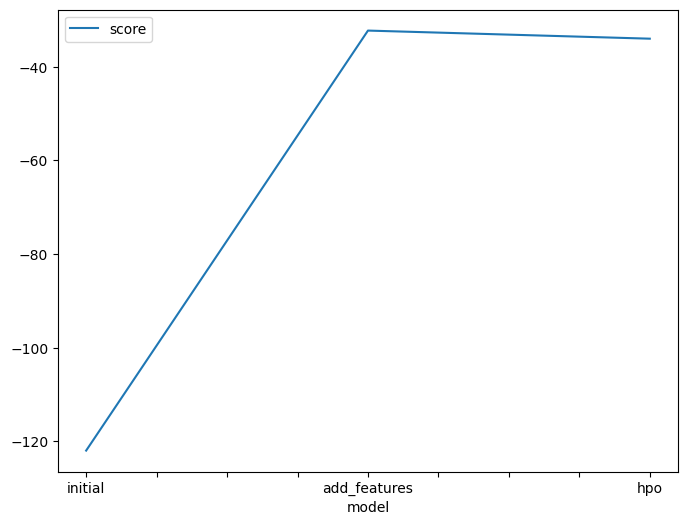

```python
# Taking the top model score from each training run and creating a line plot to show improvement
# You can create these in the notebook and save them to PNG or use some other tool (e.g. google sheets, excel)
fig = pd.DataFrame(
    {
        "model": ["initial", "add_features", "hpo"],
        "score": [-121.978125, -32.242313, -33.973186]
    }
).plot(x="model", y="score", figsize=(8, 6)).get_figure()
fig.savefig('model_train_score.png')
```

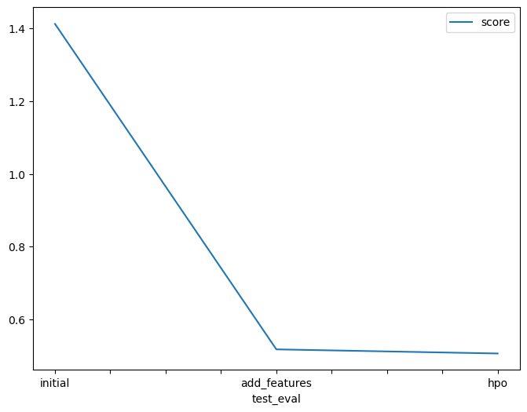

```python
# Take the 3 kaggle scores and creating a line plot to show improvement
fig = pd.DataFrame(
    {
        "test_eval": ["initial", "add_features", "hpo"],
        "score": [1.41288, 0.51764, 0.50629]
    }
).plot(x="test_eval", y="score", figsize=(8, 6)).get_figure()
fig.savefig('model_test_score.png')
```

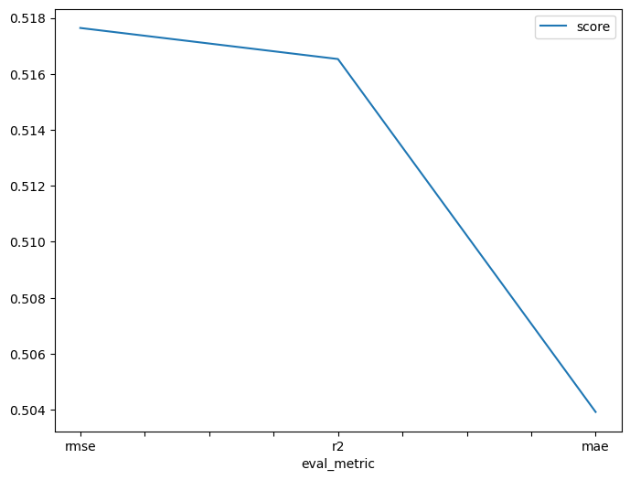

```python
# Take the 3 kaggle scores and creating a line plot to show improvement with the evaluation metric
fig = pd.DataFrame(
    {
        "eval_metric": ["rmse", "r2", "mae"],
        "score": [0.51764, 0.51653, 0.50392]
    }
).plot(x="eval_metric", y="score", figsize=(8, 6)).get_figure()
fig.savefig('model_test_score_metrics.png')
```

```python
# Summary of results for individual algorithms
results = {
    "Model_Name": ["LightGBM","CatBoost","XGBoost","TabM","RandomForest",
                   "ExtraTrees","KNeighbors","LinearModel","NeuralNetTorch","NeuralNetFastAI"],
    "Model_Score": [-35.130899,-35.210942,-35.246729,-33.189167,-38.647406,
                    -39.759523,-109.739422,-142.359675,-38.500403,-45.227535],
}

results_df = pd.DataFrame(results)
print(results_df)
```

```
        Model_Name  Model_Score
0         LightGBM   -35.130899
1         CatBoost   -35.210942
2          XGBoost   -35.246729
3             TabM   -33.189167
4     RandomForest   -38.647406
5       ExtraTrees   -39.759523
6       KNeighbors  -109.739422
7      LinearModel  -142.359675
8   NeuralNetTorch   -38.500403
9  NeuralNetFastAI   -45.227535
```

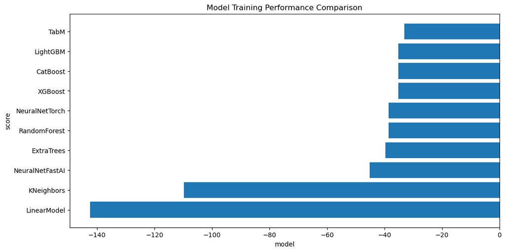

```python
# Create a plot to compare model scores
sort_results = results_df.sort_values(by = "Model_Score")
plt.figure(figsize=(12, 6))
plt.barh(sort_results["Model_Name"], sort_results["Model_Score"])

# Add labels and a title
plt.xlabel('model')
plt.ylabel('score')
plt.title('Model Training Performance Comparison')

# Display the chart
plt.savefig('model_comparison.png')
plt.show()
```

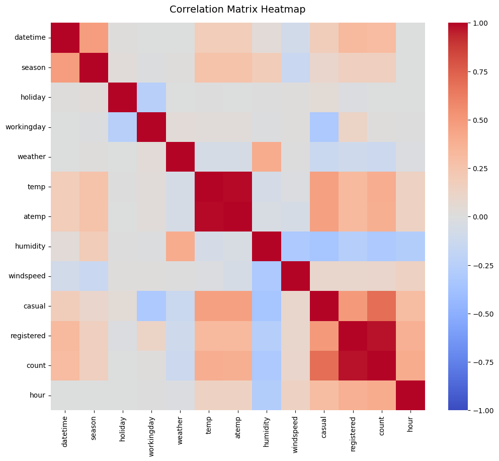

```python
# Create correlation matrix heatmap for all features
corr_matrix = train.corr()
plt.figure(figsize=(12, 10))
sns.heatmap(
    corr_matrix,
    cmap="coolwarm",  # Diverging colormap (blue = negative, red = positive)
    vmin=-1,
    vmax=1,  # Set color limits to match standard correlation range
)

plt.title("Correlation Matrix Heatmap", fontsize=14, pad=15)
plt.savefig('correlation_heatmap.png')
plt.show()
```

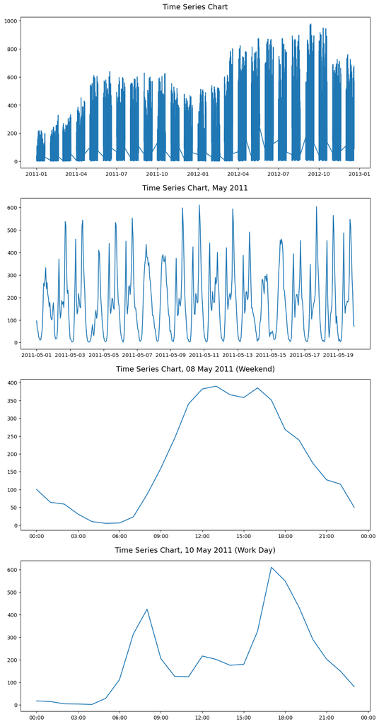

```python
# Create a time series plot of bike-sharing demand
fig, axs = plt.subplots(4, 1, figsize=(12, 24))

# Create a time series plot of bike-sharing demand for the entire dataset
axs[0].plot(train['datetime'], train['count'])
axs[0].set_title("Time Series Chart", fontsize=14, pad=15)

# Create a time series plot of bike-sharing demand for May 2011
mask1 = ((train['datetime'].dt.month == 5) & (train['datetime'].dt.year == 2011))
axs[1].plot(train['datetime'][mask1] , train['count'][mask1])
axs[1].set_title("Time Series Chart, May 2011", fontsize=14, pad=15)

# Create a time series plot of bike-sharing demand for 08 May 2011
mask2 = ((train['datetime'].dt.day == 8) & (train['datetime'].dt.month == 5) & (train['datetime'].dt.year == 2011))
axs[2].plot(train['datetime'][mask2] , train['count'][mask2])
axs[2].set_title("Time Series Chart, 08 May 2011 (Weekend)", fontsize=14, pad=15)

# Create a time series plot of bike-sharing demand for 08 May 2011
mask3 = ((train['datetime'].dt.day == 10) & (train['datetime'].dt.month == 5) & (train['datetime'].dt.year == 2011))
axs[3].plot(train['datetime'][mask3] , train['count'][mask3])
axs[3].set_title("Time Series Chart, 10 May 2011 (Work Day)", fontsize=14, pad=15)

## Change time format on the x-axis to hours
hour_fmt = mdates.DateFormatter('%H:%M')
axs[2].xaxis.set_major_formatter(hour_fmt)
axs[3].xaxis.set_major_formatter(hour_fmt)

# Add labels and a title
plt.savefig('time_series.png')
plt.show()
```

### Hyperparameter table

```python
# The 3 hyperparameters we tuned with the kaggle score as the result
pd.DataFrame({
    "model": ["initial", "add_features", "hpo"],
    "hpo1": [100, 100, 3000],
    "hpo2": [31, 31, 100],
    "hpo3": [0.1, 0.1, 0.05],
    "score": [1.41288, 0.51764, 0.50629]
})
```

|  | model | hpo1 | hpo2 | hpo3 | score |
| --- | --- | --- | --- | --- | --- |
| 0 | initial | 100 | 31 | 0.10 | 1.41288 |
| 1 | add_features | 100 | 31 | 0.10 | 0.51764 |
| 2 | hpo | 3000 | 100 | 0.05 | 0.50629 |